# Methodology

## 6.3. Modelling data measured as proportions (0 to 1 scale)

At least 4 ways of doing it:

**1. Linear probability models**

In the world of econometrics, having the fitted regression line go outside the 0–1 range is fine. Linear probability model (LPM) models data like this, and for values that aren’t too extreme (the outcome ranges between 0.2 and 0.8), the results are generally equivalent to fancier non-linear models. LPMs are even arguably best for experimental data.

**2. Fractional logistic regression**

Logistic regression is normally used for binary outcomes, but you can use it for proportional data too. This kind of model is called fractional logistic regression. `glm(..., family = quasibinomial(link = "logit"))`.

**3. Beta regression**

An alternative to the above mean-focused regression is to use distributional regression to estimate not lines and averages, but the overall shapes of statistical distributions. `brm(bf(proportion ~ x, phi ~ x), data = d, family = Beta()` This usues the parametrization of Beta distribution: $\mu$ and $\phi$ (location and variance).

One problem with beta regression is that the beta distribution does not include 0 and 1. If your data has has 0s or 1s, the model breaks.

**4. Zero-inflated beta regression**

We still model the mean and precision of the beta distribution, but we also model one new special parameter $\alpha$. With zero-inflated regression, we are modelling a mixture of data-generating processes:

1. A logistic regression model that predicts if an outcome is 0 or not, defined by $\alpha$.
2. A beta regression model that predicts if an outcome is between 0 and 1 if it’s not zero.

The only difference between regular beta regression and zero-inflated regression is that we have to specify one more parameter: zi. This corresponds to the $\alpha$ parameter and determines the zero/not-zero process. `brm(bf(prop_fem ~ quota,phi ~ quota,zi ~ 1), data = d,family = zero_inflated_beta())`

But what if you have both 0s and 1s in your outcome? There is a variation for zero-one-inflated beta (ZOIB) regression. ZOIB regression models a mixture of three things:

1. A logistic regression model that predicts if an outcome is either 0 or 1 or not 0 or 1, defined by $\alpha$ (or alternatively, a model that predicts if outcomes are extreme (0 or 1) or not (between 0 and 1).
2. A logistic regression model that predicts if any of the 0 or 1 outcomes are actually 1s, defined by $\gamma$ (or alternatively, a model that predicts if the extreme values are 1)
3. A beta regression model that predicts if an outcome is between 0 and 1 if it’s not zero or not one (or alternatively, a model that predicts the non-extreme (0 or 1) values).

```r
brm(
  bf(
    outcome ~ covariates,  # The mean of the 0-1 values, or mu
    phi ~ covariates,  # The precision of the 0-1 values, or phi
    zoi ~ covariates,  # The zero-or-one-inflated part, or alpha
    coi ~ covariates  # The one-inflated part, conditional on the 0s, or gamma
  ),
  data = d,
  family = zero_one_inflated_beta())
```

Also see:

https://mvuorre.github.io/posts/2019-02-18-analyze-analog-scale-ratings-with-zero-one-inflated-beta-models/

What if your proportion-based outcome has a bunch of 1s and no 0s? There are two ways to do one-inflated regression:

1. Reverse your outcome so that it is 1 - outcome instead of outcome and then use zero-inflated regression.
2. Use zero-one-inflated beta regression and force the conditional one parameter (coi, or the $\gamma$ in that model) to be one, meaning that 100% of the 0/not 0 splits would actually be `bf(..., coi = 1)`.

# 7. Multilevel models.

Multilevel models are used to model data that falls naturally into groups. In these cases we can partition variation (i) into data level variation and (ii) into between-groups variation. The data level variation is captured by SD, as in ordinary single-level regression, and the between-groups variation is really the SD of group means. So if we have 100 test scores from 10 schools, then this between-schools variation is calculated as standard deviation from 10 estimated school mean scores (and the data level variation comes from the 100 tests). Technically, this means that we treat the school means as parameters to be estimated on data (individual test scores), but at the same time we also treat the school means as data in their own right, which we use to estimate a meta-parameter, $\sigma_{school}$ (the SD of school means). Thus, in their data guise, we model the school means as sampled from a gaussian meta-distribution of school means (called “meta-prior”).

The beauty of this approach is that during fitting of the model, information flows from the data into all levels of the model (individual level and the school level) and also moves between the levels. So the parameters for each school are informed both by data coming from this school, and data coming from all other schools. This way we use data more efficiently.

## 7.1. ANOVA-like models for fighting false alarms

We have a table containing i rows, where for each row corresponds to (1) a single pupils math score, (2) his/hers school name, (3) sex and (4) as a school-level variable the number of pupils in that school. There are j schools in this four-column table and each pupil has a single score from a single school. For brevity lets name the columns as follows:

y - score

sch - school name (index) as a factor

We start, again, by simply modeling y as a normal distribution. This model says that the scores are randomly drawn from a normal distribution of scores, whose parameters are determined on the actual scores.

The model looks like this

$$y_i \sim N(\mu, \sigma)$$
$$\mu = \alpha$$
or written more concisely in a single line:

$$y_i \sim N(\alpha, \sigma)$$

Here we simply redefine $\mu$ as $\alpha$ or intercept. This is mathematically meaningless, but will come handy later, when we start adding predictors to the model. *N* stands for *Normal distribution*, plus priors for the 2 parameters ($\mu$ and $\sigma$). In R modelling language this can be written as $y \sim 1$. This model knows nothing about pupils belonging to different schools and it is the *complete pooling model*.

In the model description equal sign (=) means deterministic redefinition, tilde ($\sim$) means stochastic relation.

The opposite, *no-pooling model*, models the mean of each schools score completely independently from other schools (but it may or may not model the pupil level SD as identical across the scools, a.k.a. as full data average):

$$within ~school~ j: y \sim N(\alpha_j, \sigma_y)$$

This mathematical description means that there are as many models as there are schools (thus j models), each with its own $\mu$, which is renamed as $\alpha$ or intercept in the regression language. $\alpha_j$ means that there are j different alpha coefficients, each standing in for a mean score of a different school. There is also a single data level SD of all scores for all schools, $\sigma_y$, which is the same thing as the $\sigma$ in the previous model.  
In R language this model is $y \sim 0 + sch$.

And the version where both mean and SD are modelled completely independently looks like this:

$$y_i \sim N(\alpha_j, \sigma_{y[j]})$$
or $bf(y \sim 0 + sch, sigma \sim 0 + sch)$ (This version works in brms).

If there are plenty of data for each school, then this sort of model would be good for assessing the mean test result for each school.

But what, if some schools have only a few datapoints? Then there we will see some schools, where only a few students took the test and where the results might not be representative of the actual quality of the school. We are wary of extreme results from such schools, but we do not want to ignore them either. What we can do instead, is to build a model where estimates of the mean scores for all schools are shrunk towards the mean score of all schools. We do this by adding another 2nd level regression model.

$$y_i \sim N(\alpha_j, \sigma_y)$$
$$\alpha_j \sim N(\mu_{\alpha}, \sigma_{\alpha})$$

in brms this 2-level model reads as $y \sim 0 + (1 \vert sch)$

The second row of this model says that the school-specific mean scores themselves come from a normally distributed infinite population of mean scores.

This model has j + 3 parameters:

- j $\alpha$-s - j mean scores, one for each school,
- $\sigma_y$ - SD of the scores (showing the distribution of the scores),
- $\sigma_{\alpha}$ - SD of the school-specific mean scores, not individual scores,
- $\mu_{\alpha}$ - the mean of the j $\alpha$ coefficients of the individual schools, which is not the mean(score), but the mean of the mean scores.

We can re-write the previous model like this:

$$y_i \sim N(\alpha + \alpha_j, \sigma_y)$$
$$\alpha_j \sim N(0, \sigma_{\alpha})$$

Here we get the common mean score over all schools as $\alpha$ and deflections from this for each individual schools ($\alpha_j$), which should be added together, to get the estimate for j-th school. In brms this model is $y \sim 1 + (1 \vert sch)$. This form of the model, while mathematically equivalent, is a bit easier to fit, and arguably to work with.

To recap:

- In the no-pooling model, the $\alpha_j$-s correspond to j school means.
- With complete pooling the $\alpha_j$-s are all fixed at a common $\alpha$.
- In the multilevel model $\alpha_j$-s are assigned a probability distribution, whose 2 parameters are estimated directly from data. The distribution pulls the estimates of $\alpha_j$ toward the mean level $\mu_{\alpha}$, but not all the way.
- If $\sigma_{\alpha} \rightarrow \infty$, there is no pooling;
- If $\sigma_{\alpha} \rightarrow 0$, the estimates are pulled to zero, giving complete pooling.

The last 2 points mean that single-level models can be viewed as special cases of multilevel models. Thus, even if we only have 2 groups, or many of the groups have very small N, the multi-level model is at least as good as the corresponding single-level model!

One way to interpret the variation between schools, $\sigma_{\alpha}$, is through the ratio, $\sigma_{\alpha}/\sigma_y$. If the ratio is small, then most of the variation in scores is at the pupil level and the schools are very similar to each others. Otherwise, different schools have different mean scores. The goal of the model is to look beyond the samples of scores from each school and into the true mean ability of each schools students, as if each school contained an infinite number of test takers whose average ability is the issue.

Lets suppose that the fitted data level SD, $\sigma_y$, is 0.74 and the SD for the mean scores, $\sigma_{\alpha}$, is 0.33. Then we can see that to get from 0.74 to 0.33, we have to divide 0.74 with square root of 5. This means that the SD of mean scores is the same as the SD of 5 individual score measurements, and that the amount of information in this 2nd level distribution of the means is the same as that in 5 measurements within a school. Thus, a school with <5 scores, puts more information into the group-level model than into the schools own model (in the sense of providing a higher-SD estimate of the schools mean score). As a result, the mean score estimate in an N<5 school is closer to the complete-pooling estimate, and closer to the no-pooling estimate when N>5.

We can express this very same 2-level model in an alternative way by putting priors on priors, that is, by using meta-priors. With the meta-priors we assume that the scores of each school have their own distribution that partially overlaps with the other schools, and that these school-specific distributions of test scores come from a single overarching meta-distribution, defined by the meta-prior.

By using the meta prior, we turn our usual school-specific prior, over which the meta-prior arches, into an adaptive prior. For this we take the school-specific prior $\alpha_{j} \sim normal(0, .)$, where the dot stands for some concrete sigma value that you care to put there, and substitute this value with another parameter, $\sigma_{sch}$, that needs to be fitted on data (on j school means). Tis way the adaptive prior will contain an additional parameter, which in turn needs a meta-prior to be fitted.

During fitting the meta-prior allows using school-specific information laterally, across the schools, leading to partial pooling of information and to shrinkage. Information flows from an individual school up to the meta-prior, and down again to other schools.

$$y_i \sim N(\mu, \sigma)$$
$$\mu = \alpha + \alpha_{j}$$
$$\alpha \sim N(.,.)$$
$$\alpha_{j} \sim normal(0, \sigma_{sch})$$
$$\sigma_{school} \sim cauchy(.)$$
$$\sigma \sim exponential()$$

adaptive prior for each school

meta-prior

prior for the student-level SD

Schemes of the non-adaptive 1-level model and of the adaptive 2-level model.

[figure not shown]

It is easy to expand this model by adding another level. If we suppose that the meta-prior denotes school district, we cold simply turn it into another adaptive prior by putting another 2nd-level parameter into it, and then adding another meta prior (3d level), to denote the city. Then we have each school under 2 levels: schools belong to school districts, and school districts belong to the city.

When to use multi-level models? The answer is that using them should be your default position whenever data generating process contains grouping structures that have distinct variations. Such groups can be defined by schools, cities, countries, enzyme batches, study centers, experimenters.

> If you think that there is something in common between the groups, but also something different, consider using a multi-level model. If you think that there is everything in common (the variation of each group is identical to all others), then ignoring the groups and running a single 1-level model should not change the result.

Simple single-level models are often bad for hierarchical data: with few parameters, they cannot fit large datasets well, whereas with many parameters, they tend to overfit. Multilevel models can have enough parameters to fit the data well, while using a population distribution helps to avoid overfitting. It is often sensible to fit hierarchical models with more parameters than there are data points.

When j is small, it is difficult to estimate the $\sigma_{\alpha}$ and multilevel modeling often adds little beyond no-pooling models. When $\sigma_{\alpha}$ cannot be estimated well, it tends to be overestimated, and so lead to no pooling. With 1 or 2 groups multilevel modeling reduces to classical regression. Even 2 observations per group is enough to fit a multilevel model. It is even acceptable to have 1 observation in many of the groups. When groups have few observations, their means won’t be estimated precisely, but they can still provide information that allows estimation of the coefficients and variance parameters.

Multi-level models carry 6 main advantages:

1. a multi-level model gives more honest posteriors (CIs) for higher-level estimates (in our example, the estimated city-wide mean test score). These posteriors tend to be wider than the ones calculated from a single-level model.
2. A multi-level model allows to estimate at each level – you get an estimate for each school, for each district, and for the whole city.
3. A multi-level model defends against false alarms by shrinkage of the estimates. This is usually more efficient and also better interpretation-wise, than correcting for multiple testing by adjusting p values/CI-s – but leaving the actual effect sizes at their raw data level.
4. A multi-level model more accurately reflects clumpy data generating mechanisms in the wild. This makes it easier to give scientific interpretations to it.
5. A multi-level model allows to find batch effects and other anomalies of experimentation.
6. A multi-level model allows to generate new *in silico* data at every level, including generating new groups.

The multi-level model we introduced is a kind of Bayesian one-way ANOVA analogue (only ANOVA does not provide shrinkage). This model is much easier to expand than ANOVA models. We can substitute the normal likelihood with biomial likelihood, for example to do a similar shrinkage model for fractions, and/or we can easily turn this into a full linear, or generalized linear, or even non-linear regression model (see next chapters). All of these models provide shrinkage and take into account the clumpiness in your data.

When not to use multi-level models? Avoid them if your groups do not come from a single overarching super-group. For example, if you have several control groups and a single experimental group, then putting them together under a single meta-prior can lead to too much shrinkage for the experimental group. But if you have several control groups and several experimental groups, then its perfectly all right to put both kinds of groups under their own meta-prior.

To test our intuition, lets build an artificial dataset of 10 schools that have identical “true” means of test results, each = 100, drawn from a normal distribution with SD=25. The 10 schools have different numbers of test-takers: 1 in school 1, 2 in school 2, 3 in school 3, …, 10 in school 10.

Here are the first 6 rows

| value | ID |
| --- | --- |
| 120.00000 | 1 |
| 100.46865 | 2 |
| 95.39369 | 2 |
| 65.71674 | 3 |
| 85.02081 | 3 |
| 107.36363 | 3 |

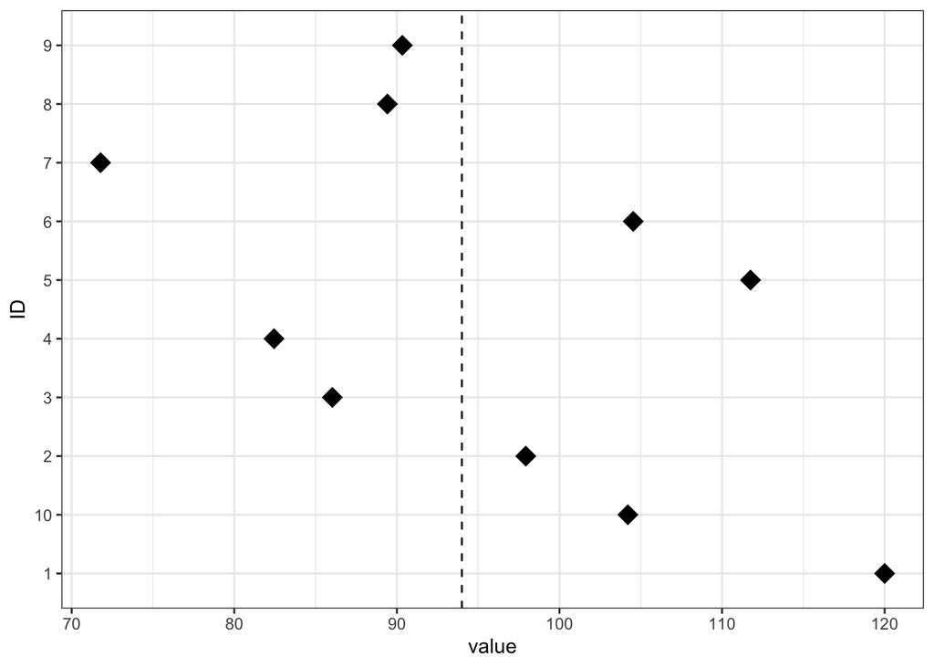

The empirical sample means of the 10 schools. All samples have randomly drawn from the same population (mean = 100, SD = 25). The global sample mean, at 94, is shown as dotted line

In the next graphs we are going to show not the full means, but school-specific estimates of deflections from the overall mean (over all the schools).

Our first model treats all schools completely independently. There is no information transfer between schools. We use reasonable priors (not very strong, but not very weak either) for mean and SD. This considerably narrows our estimates in schools where N is very small.

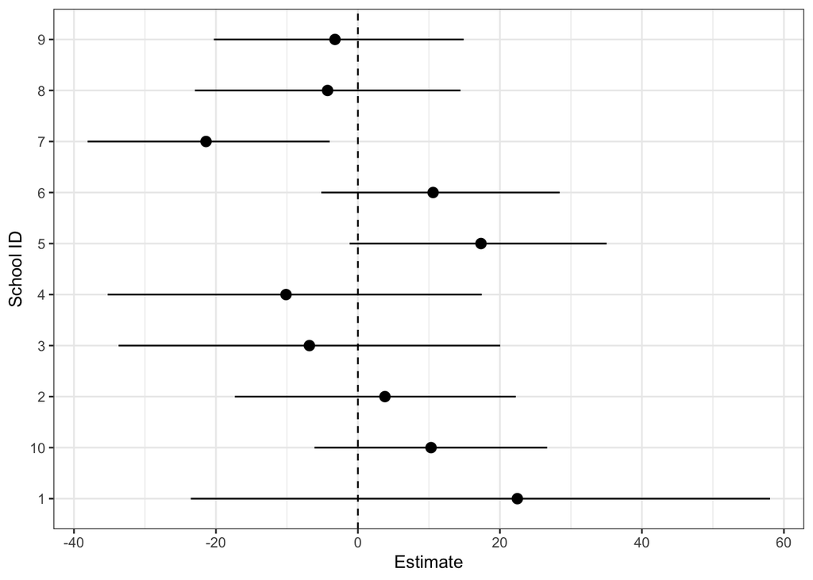

The estimates for mean test result with 95 percent CIs for each school, modeled completely independently.

In school 1, where a single student took the test, thanks to the prior we still have a reasonably informative estimate for that school – we believe that this school could be somewhere from 25% below average to about 50% above average. With a single student it would be strange, if our estimate would be much more precise.

Next we present a model, where school means are completely independent, but school SD-s are completely pooled.

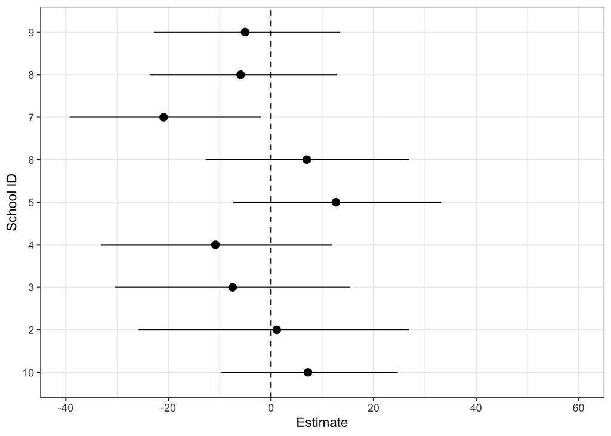

Classical linear regression estimates the means independently, while completely pooling information on variation across the schools.

The pooling of variation information narrows our CIs a bit, but not that much.

And now a 2-level model, which partially pools information on the means, leading to shrinkage towards the global mean.

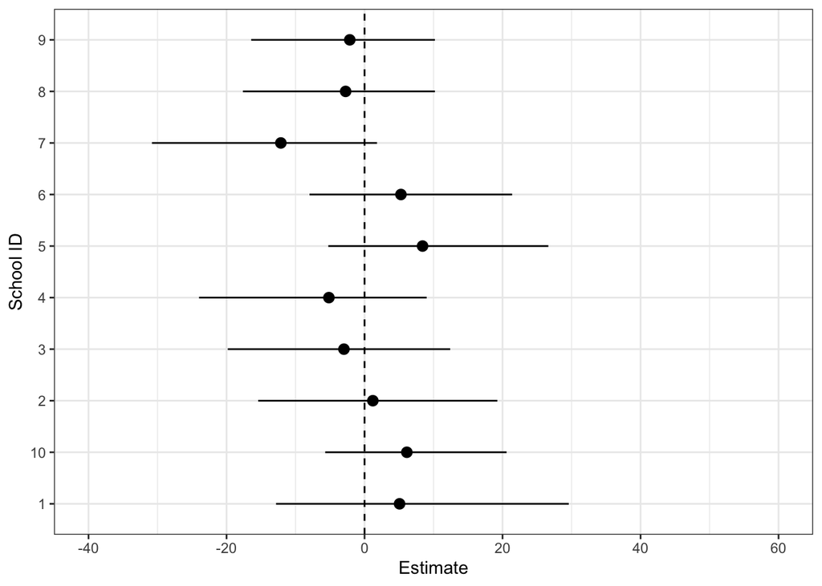

The 2-level model results in shrunk estimates.

Here the CI-s are clearly narrower.

Finally we plot out the actual shrinkage for each school

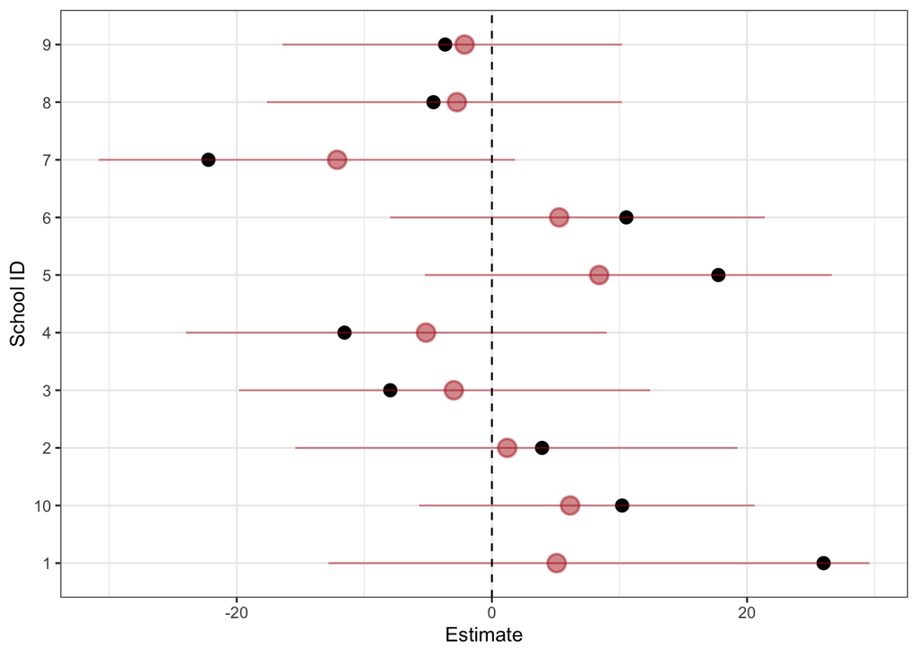

## 7.2. Multilevel regression models: free intercepts

Now we add two predictors to our schools example: X - is students sex (male = 1 or female = 0) and S - is the school type (gymnasium or not). S is a group-level predictor, so there is only one S value per school, which is repeated in the table for all pupils in this school.

We start with converting the simple regression $y = \alpha + \beta_1x + \beta_2s + \beta_3sch + error$ into a 2-level model. In brms notation this model is $y \sim x + s + (1 \vert sch)$.

$$Within ~school ~j: y_i \sim \alpha + \alpha_j + \beta x_i + N(0, \sigma_y)$$

$$\alpha_j \sim \gamma_0 + \gamma_1 s_j+ N(0, \sigma_{\alpha})$$

## 7.3. Free intercepts and slopes

## The variance-covariance matrix for classical regression

In typical classical regression settings the model $y \sim N(\beta_0 + \beta_1x, \sigma)$ the variation, sigma, is modelled to be the same for each level of the predictor(s). We can write this out as sigma becoming a variance covariance matrix

```r
$$ V = cov = \begin{equation}
  \begin{pmatrix}
    \sigma & 0 & \ldots & 0 \\
    0 & \sigma & \ldots & 0 \\
    \vdots & \vdots & \ddots & \vdots \\
    0 & 0 & \ldots & \sigma
  \end{pmatrix}
\end{equation}$$
```

$$V = cov = \begin{equation}
\begin{pmatrix}
\sigma & 0 & \ldots & 0 \\
0 & \sigma & \ldots & 0 \\
\vdots & \vdots & \ddots & \vdots \\
0 & 0 & \ldots & \sigma
\end{pmatrix}
\end{equation}$$
where sigma-s on the diagonal denote SD-s and zeros denote correlations $\rho$ between predicted values at different predictor values. These fixed zero-correlations mean that the model knows data to be independent. The model also knows that all sigmas are equal, hence the homogeneity of variance.

Now, in the multilevel model we have dissected the 2nd level variation between two sigmas, one for the variation of intercepts, and another for the variation of slopes, so the matrix loses its zero-correlations and gets a parameter for each correlation to be estimated. These parameters are identical below and above the diagonal of the matrix. The simple case of sigmas for intercept and slope is shown right below.

## The free intercept, free slopes model

First the model without school-level variable S – $y \sim 0 + x + (x \vert sch)$ in brms syntax.

$$y_i \sim N(\alpha_{j[i]} + \beta_{j[i]} x_i, \sigma_y)$$
$$\binom{\alpha_j}{\beta_j} \sim MVN(\binom{\mu_{\alpha}}{\mu_{\beta}}, \binom{\sigma_{\alpha}~~~~~\rho_{\sigma_{\alpha} \sigma_{\beta}} }{\rho_{\sigma_{\alpha} \sigma_{\beta}} ~~~~~ \sigma_{\beta}})$$

where $\rho$ models between-the-groups correlation. Here we have the two 2nd level regressions (the 1st of which treats intercepts as the predicted variable and the 2nd does the same for slopes) modelled within the same equation, with correlations between the two predicted variables (intercepts and slopes) modelled. This means that we model the school specific intercepts and slopes together, so that there is also partial pooling of information between intercepts and slopes, and we estimate the correlation between mean scores and the rate of change in the mean scores accross schools. The likelihood here is multivariate normal (MVN).

If we have population-level intercept and slope in the model like this
$$y_i \sim N(\alpha_i + \alpha_{j[i]} + \beta_i + \beta_{j[i]} x_i, \sigma_y)$$
then the second level gets to be simpler:

$$\binom{\alpha_j}{\beta_j} \sim N(\binom{0}{0}, \binom{\sigma_{\alpha}~~~~~~~~~\rho_{\sigma_{\alpha} \sigma_{\beta}} }{\rho_{\sigma_{\alpha} \sigma_{\beta}} ~~~~~~~~~ \sigma_{\beta}})$$

The brms notation is $y \sim x + (x \vert sch)$.

We now expand this 2nd part of the model to include the school-level predictor S.

$$\binom{\alpha_j}{\beta_j} \sim N(\binom{\gamma_0{^ \alpha} + \gamma_1 {^ \alpha} u_j}{\gamma_0{^ \beta} + \gamma_1 {^ \beta} u_j}, \binom{\sigma_{\alpha}~~~~~~~~~\rho \sigma_{\alpha} \sigma_{\beta}}{\rho \sigma_{\alpha} \sigma_{\beta} ~~~~~~~~~ \sigma_{\beta}})$$
Its brms version reads $y \sim x + s + x:s + (x \vert sch)$, so we have an interaction between the school type and sex of the pupil. Varying slopes can be considered as interactions between group indicators and an individual-level predictor.

Sometimes it might be reasonable to allow the slope, but not the intercept, to vary. When J separate experiments are performed on samples from a common population, with each experiment randomly assigning a control condition to half its subjects and a treatment to the other half, while the “controls” are the same for each experiment but the “treatments” vary. Then we remove the intercept from the group of coefficients that vary by group $y \sim T + (T - 1 \vert sch)$ where T is the treatment variable ${0, 1}$. Now we get a different treatment effect for each school.

And here is a model with an individual-level predictor x: $y \sim x + T + (T + x:T - 1 \vert sch)$, where the treatment effect and its interaction with x vary by school

There is nothing wrong with a high correlation between the $\alpha$s and $\beta$s. As with interaction models in classical regression, centering the predictor(s) may not remove these correlations, but the correlation is easier to interpret.

## Recap: multilevel structures

Imagine that you have student scores from 10 schools. If score variable is y, then the model is

for j-th school:

$$y_i = \beta_{j} + N(0, \sigma) ~~or~~ y_i \sim N(\beta_j, \sigma)$$

or

$$y_i \sim N(\mu, \sigma)$$
$$\mu = \beta_j$$

where i is the student index (a.k.a. row index in the data table) and j {1 … 10} is the school index. There are 10 separate models, one for each school, where parameters $\beta_1$ to $\beta_{10}$ are schools-specific mean scores and the parameter $\sigma$ marks the identical SD of scores for all 10 schools. If we have 10 intercepts/means, then we can imagine the distribution of intercepts as

$$\beta_j \sim N(\mu_{mean}, \sigma_{mean})$$

The distribution has 2 parameters, $\mu_{mean}$ and $\sigma_{mean}$. This meta-distribution of means can be constructed from observed data means, but it also doubles as a prior for the school-specific intercept. This leads to a situation, where in the model we have an ordinary prior for $\sigma$, where the parameters are fixed, based on our prior knowledge that is independent of data. And then we have this strange prior where instead of fixed coefficients we have parameters to be estimated on data. This prior we call the *adaptive prior*, because it adapts its shape on the data. So the full model becomes

$$y_i \sim N(\beta_j, \sigma)$$
$$\beta_j \sim N(\mu_{mean}, \sigma_{mean})$$
and the priors for $\sigma, \sigma_{mean}, \mu_{mean}$, where the last 2 priors are meta-priors. They are meta, because these priors are set on the parameters of another (adaptive) prior. In brms notation this is

```r
score~0 + (1|school)
#or
score~(1|school) - 1
```

In this model interesting stuff starts to happen. The adaptive prior is fitted on data (and on its meta-priors, of course), which means that information moves up from the individual school level into the 2nd level adaptive prior. But then, as this is still a prior, it is also used for fitting the 1st level model of individual schools. So the information also flows the other way, from the adaptive prior down to individual schools, whose score means are calculated partly on information encoded in the shape of the adaptive prior. Because of this up-and-then-down information flow, the data coming from a school, which is used to estimate the mean score of this particular school, is also used to fit the adaptive prior. Thus information coming from any school affects the estimation of all other schools means, to some extent. So every school has an influence on all other schools. This partial pooling of information between school means leads to shrinkage of the $\beta_j$ coefficients towards a common mean.

As with ordinary priors, the strength of the influence that an adaptive prior has on the final estimation depends both on how much information we put into this prior, as well as on how much information is contained in data for every individual school (and by implication, in the likelihood function). As the adaptive prior gets its information from school means, the more schools there are, the more informative (narrower) this prior will be. Also, the less variation there is between the school means, the narrower the adaptive prior will be, and thus the more influence (more shrinkage) it will have on the school-specific posteriors. On the other hand, the more scores go into the likelihood for a given school, and the less variation there is within these scores, the more will the posterior depend on the schools own scores, which means that there will be less shrinkage for these particular schools.

We can reduce the number of parameters that are estimated by providing a common intercept $\beta_0$ for all schools, to which individual school-specific intercepts are then added to yield a schools mean score (mean score for j-th school = $\beta_0 + \beta_j$).

$$score \sim N(\beta_0 + \beta_j, \sigma)$$
$$\beta_j \sim N(0, \sigma_{mean})$$
and priors for $\sigma, \beta_0, \sigma_{mean}$.

There are j - 1 parameters less in this otherwise equivalent model, and the brms notation is

```r
score~1 + (1|school)
#or
score~(1|school)
```

Next we relax the stupid assumption that all schools have identical SD of scores. Now we have 2 adaptive priors, one of which models the distribution of mean scores for each school and the other the distribution of SD-s of scores for each school. Of corse both distributions, modelled as normal, have their own mu and sigma parameters.

$$score \sim N(\mu, \sigma)$$
$$\mu = \beta_j$$
$$\sigma = \beta_{s[j]}$$
$$\beta_j \sim N(\mu_{mean}, \sigma_{mean})$$
$$\beta_{s[j]} \sim N(\mu_{sd}, \sigma_{sd})$$

and the priors for $\mu_{mean}, \sigma_{mean}, \mu_{sd}, \sigma_{sd}$. We can get rid of the $\mu_{mean}$ and $\mu_{sd}$ parameters as we did before.

Now the respective brs models are

```r
bf(score~0 + (1|school), sigma~0 + (1|school))

#and

bf(score~(1|school), sigma~(1|school))
```

So now we start our model description with the likelihood, followed by 2 re-definitions of parameters, followed by 2 adaptive-priors, followed by 4 ordinary priors, followed by 4 meta-priors.

If in addition we want to model the correlations between the mean scores and within-school variarion in scores, then the model becomes

```r
bf(score~(1 |id| school),
   sigma~age + (1 |id| school))
```

Where “id” denotes any string that must be the same in both submodels.

We next add a student-level predictor: students age. For modelling convenience, we standardize the ages, so that they would have a mean = 0 and sd = 1. Now, we can model these data for the 1st school as

$$score = \beta_0 + \beta_{sch1} + b_{age} \times age + N(0, \sigma)$$
.

For the next school there will be another equation

$$score = \beta_0 + \beta_{sch2} + b_{age} \times age + N(0, \sigma)$$

and so on. Again, while there are parameters that are the same for each school ($\beta_0$ - the common intercept, $b_{age}$ - the slope for the age variable, and $\sigma$ - the common SD for all schools), each school has its own intercept. So we have 10 regression equations, where there are 10 equation-specific parameters (the beta-schools) and 3 parameters ($\beta_0$, $\beta_{age}$ and $\sigma$) common to all equations. In this equation the 2nd schools intercept (mean score if age is at its mean level, e.g. age = 0) equals $\beta_0 + \beta_{sch2}$. (This is why we standardized the age-variable.) And the mean score for the 2nd school, if the age is two years over the mean age, equals $\beta_0 + \beta_{sch2} + 2 \times \beta_{age}$.

As we have 10 beta-schools coefficients, we can again build a distribution of school intercepts, which is the same as saying that we can build a distribution of school means for the situation where age = 0 = mean(age).

So far the picture looks like this

for each school:

$$score \sim N(\mu, \sigma)$$
$$\mu = \beta_0 + \beta_j + \beta_{age} \times age$$
$$\beta_j \sim N(0, \sigma_{means})$$

and priors for $\sigma_{means}$, $\beta_{age}$, $\beta_0$, and $\sigma$.

These are called the *meta-priors*, as they are priors set on parameters of another prior. Now we have the full system.

Now lets make the SD-s vary by school as well. Thus we have 2 adaptive priors: we have the distribution of school-means and we have another distribution of school-SDs. So the model loses the common $\sigma$ and at the same time gains another adaptive prior and 2 additional meta-priors.

for each school:
$$score \sim N(\mu, \sigma)$$
$$\mu = \beta_0 + \beta_j + \beta_{age} \times age$$
$$\sigma = \beta_{0.s} + \beta_{j.s} + \beta_{age.s} \times age$$
$$\beta_j \sim N(0, \sigma_{mean})$$
$$\beta_{j.s} \sim N(0, \sigma_{sd})$$

and priors for $\sigma_{sd}$, $\sigma_{mean}$, $\beta_{age.s}$, $\beta_{age}$, $\beta_{0.s}$, and $\beta_0$.

So now we start our model description with the likelihood, followed by 2 re-definitions of parameters, followed by 2 adaptive-priors, followed by 4 ordinary priors, followed by 2 meta-priors.

In this model we have liberated the intercepts to vary between schools. In brms notation the models are

```r
score ~ age + (1 | school)
```

and

```r
bf(score~age + (1 | school),
   sigma~age + (1 | school))
```

We can, and will, as easily liberate the slopes as well, by giving them adaptive priors of their own. Then we will have our final model with 4 adaptive priors and with the corresponding 8 meta-priors. In brms notation this model looks like this

```r
bf(score~age + (age || school),
   sigma~age + (age || school))
```

In this model both intercepts and slopes vary accross schools. Two vertical lines mean that the correlation between schools intercepts and slopes (mean score at mean age vs. change in the mean score when age is changed) is not modelled. We can incorporate this correlation into the model like this

```r
bf(score~age + (age | school),
   sigma~age + (age | school))
```

In this model we also estimate the correlation between the intercepts and slopes of the school means (the 1st submodel) and simultaneously the correlation between intercepts and slopes of the school SDs (the 2nd submodel). If the schools means submodel intercepts and slopes are positively correlated, then the schools with higher scores also tend to have faster growth of scores, as the students get older. If the schools SD submodel intercepts and slopes are positively correlated, then the schools with higher within-school variation between scores also tend to have faster growth of this variation, as the students get older.

We can add another layer of correlations to this model like this

```r
bf(score~age + (age |id| school),
   sigma~age + (age |id| school))
```

Where “id” denotes any string that must be the same in both submodels. Now we estimate the same correlations as before, but in addition also the correlations between the submodels. For instance there might be a negative correlation between schools mean scores and variation within schools so that schools that have higher mean scores tend to have less variation between the scores.

And finally, lets incorporate a school-level variable Z, school size (the nr of students) into the regression. For simplicity we are using the free intercept model that assumes equal variance for all schools.

for each school:

$$y_i \sim N(\mu, \sigma)$$
$$\mu = \beta_0 + \beta_j + \beta_{age} \times age_i$$
$$\beta_j \sim N(\mu_{mean}, \sigma_{mean})$$
$$\mu_{mean} = \beta_{mean} + \beta_z \times z_j$$

and the priors for every parameter and meta-parameter: $\beta_0, \beta_{mean}, \beta_z, \beta_{age}, \sigma_{mean}, \sigma, \beta_z:\beta_{age}$.

In brms notation:

```r
score~age + z + age * z + (1|school)
```

As you can see, this is an interaction model, where the z variable, which is modelled at the 2nd level, interacts with the age variable, which is modelled at the first level. The group-specific variables have a single value per group, and they naturally belong to the group-level model.

Finally, as a comparison, lets have another look at a single-level interaction model:

$$y_i \sim N(\mu, \sigma)$$
$$\mu = b_0 + \gamma \times x + b_2 \times Z$$
$$\gamma = b_1 + b_3 \times Z$$

and priors for 4 betas and 1 sigma. This model can be re-written in a single line as $y = b_0 + b_1X + b_2Z + b_3XZ + N(0, \sigma)$, as any multilevel model can be turned into a single-line expression. The main goal in doing an interaction model vs a multilevel model is basically the same - to model how the slope on X varies by the levels of the Z variable, and the main difference from multilevel models is that in the single-level interaction model the influence of Z on X is modeled as deterministic. Thus, there are no adaptive priors, no partitioning of variation, no partial pooling of information, and no shrinkage.

## 7.4. Prediction from multilevel models

predict the test score for a schools males (x = 1) in j = 6. Conditional on the model parameters, the predicted value has a mean of $\alpha_{6} + \beta$ and $\alpha$ sd of $\sigma_y$.

$$y \vert \theta \sim N(\alpha_6 + \beta x, \sigma_y)$$

where $\theta$ represents the vector of model parameters. to predict the score for a male student, but in an unmeasured school, we generate a new school-level error term, $\alpha$, which we sample from its $N(\gamma_0 + \gamma_1 u_j, \sigma_{\alpha})$ distribution. The prediction will be less certain than for a student in a measured school, since we lack information about $\alpha$. From the fitted model, the within-school (residual) sd is $\sigma_y$, and the between-county sd is $\sigma_{\alpha}$. The score for a new student in a measured school can be measured to an accuracy of about +/- $\sigma_y$. The score for a new student in an unmeasured school can be predicted to an accuracy of $\sqrt{\sigma_y + \sigma_{\alpha}}$. The equation $\frac{\sqrt{\sigma_y + \sigma_{\alpha}}}{\sigma_y} - 1$ gives the percentage by which a predictive interval for a new student in an unmeasured school is wider than that of a new student in a measured school.

In principle there are 3 ways how to predict from multi-level models. When we talk about average marginal effects, we have to be explicit about what kinds of averages we are working with. We can calculate

1. Global grand mean
2. Conditional effects for existing groups
3. Conditional effects for a single hypothetical group, either typical or brand new.

For posterior prediction for a global grand mean, we calculate the mean score while ignoring any school-specific deviations of the intercept or slope. We do not incorporate school-specific information from the model into the predictions. The resulting average transcends school differences. Although the global mean only uses the “fixed” effects part of the model, these fixed effect estimates are themselves conditional on the random effects, so you still end up with a conditional prediction.

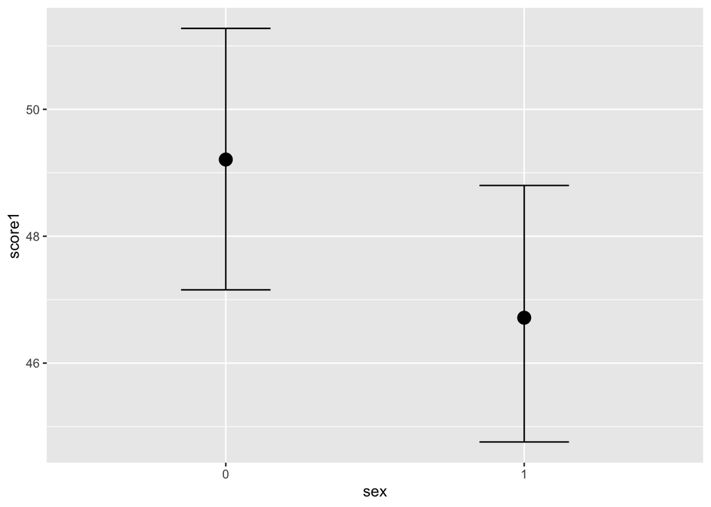

```r
sch <- read_csv("data/schools.csv")
sch$school <- as.character(sch$school)
sch$sex <- as.character(sch$sex)
l8_m1 <- brm(score1~sex+ (sex|school), data=sch, file="models/l8_m1")
conditional_effects(l8_m1)
```

We must include `re_formula=NA` explicitly, so that group level effects are ignored and school variable id is not asked for in the newdata argument.

```r
nd1 <- data.frame(sex=c("0", "1"))
pr1 <- fitted(l8_m1, re_formula=NA, newdata = nd1) %>% as.data.frame()
bind_cols(nd1, pr1)
```

```
##   sex Estimate Est.Error     Q2.5    Q97.5
## 1   0 49.20666  1.036215 47.15468 51.27576
## 2   1 46.72225  0.995492 44.75680 48.80006
```

and the overall effect size is …

```r
nd1 <- data.frame(sex=c("0", "1"))
pr1 <- posterior_epred(l8_m1, re_formula=NA, newdata = nd1) %>% as.data.frame()
posterior_summary(pr1$V1 - pr1$V2)
```

```
##      Estimate Est.Error     Q2.5    Q97.5
## [1,]  2.48441  0.667096 1.215459 3.850945
```

Posterior prediction for same clusters: When working with the same clusters that were used to fit the model, varying intercepts are just parameters. The only trick is to ensure that you use the right intercept for each case in the data. Instead of calculating a grand mean without any group information, we can incorporate school effects into our predictions. We can create conditional effects for specific schools that already exist in the data, incorporating their school-specific deviations in slope and intercept.

we feed brms new data that does include one or more schools that are already in the data, and we tell it to incorporate the random effects into its predictions by including re_formula = NULL.

We can also be more explicit about which group effects to include. When using re_formula = NULL, all group effects are included. If we made a model with both region and year effects, for instance, and only wanted to predict using the region effects, we could use $re_formula = \sim (1 \vert region)$. Or if we do not want to remember that NULL means “everything”, we could also just use $re_formula = \sim (1 \vert region)$ on our basic model with just school effects. It is all the same.

for predicting the mean scores for school no 20920:

```r
nd1 <- data.frame(expand_grid(school= "20920", sex=c("0", "1")))
pr1 <- fitted(l8_m1, newdata = nd1, re_formula = NULL) %>% as.data.frame()
bind_cols(nd1, pr1)
```

```
##   school sex Estimate Est.Error     Q2.5    Q97.5
## 1  20920   0 38.81664  4.420023 29.96680 47.27831
## 2  20920   1 37.08608  4.213951 28.70682 45.34600
```

and we create 4000 new students for school no. 20920. re_formula = NULL! these are “predicted draws from posterior predictive distribiution”

```r
nd1 <- data.frame(expand_grid(school= "20920", sex=c("0", "1")))
pr1 <- posterior_predict(l8_m1, newdata = nd1, re_formula = NULL) %>% as.data.frame()
colnames(pr1) <- c("0", "1")
posterior_summary(pr1)
```

```
##   Estimate Est.Error     Q2.5    Q97.5
## 0 38.80425  12.31615 14.55952 62.68050
## 1 37.13416  11.86526 13.98128 60.24196
```

And this is the prediction of the mean scores for the same schools - see how the intervals for the mean are much narrower than for individual students. these are “fitted draws from posterior predictive distribution”.

```r
nd1 <- data.frame(expand_grid(school= "20920", sex=c("0", "1")))
pr1 <- posterior_epred(l8_m1, newdata = nd1, re_formula = NULL) %>% as.data.frame()
colnames(pr1) <- c("0", "1")
posterior_summary(pr1)
```

```
##   Estimate Est.Error     Q2.5    Q97.5
## 0 38.81664  4.420023 29.96680 47.27831
## 1 37.08608  4.213951 28.70682 45.34600
```

### Conditional effects for a single new hypothetical group, either typical or brand new

Making predictions for new clusters is a problem of generalizing from the sample. there is no unique procedure for this. As we want a single mean that also includes regional effects, we will create a new school and make predictions based on it. The thing to do depends upon the causal model, the statistical model, and your goals. If we want a single mean that also includes school effects, we simulate a hypothetical school and make predictions based on it. The difference is in how we construct this new school and think about its variation. We can build its SD based on an average SD of the existing schools, or we can simulate a new SD.

To do this, we need to include the new school in the newdata argument, but we need to include a name of a school that does not exist (or alternatively, `school = NA`). To make these extrapolated predictions, include `allow_new_levels = TRUE`. We include the random effects for school by setting `re_formula = NULL`.

Finally, we specify how to handle the variation for this imaginary new group. We either draw from the variation in all the other schools by setting `sample_new_levels = "uncertainty"` (the default), or we simulate a whole new kind of schools uncertainty using `sample_new_levels = "gaussian"`. The documentation is in `?brms::prepare_predictions`.

In summary, we have these two general approaches:

1. Create a hypothetical school that is based on the observed variation in the existing schools with `school = "a"` in the new data and `re_formula = NULL`, `allow_new_levels = TRUE`, `sample_new_levels = "uncertainty"` in the prediction function. This creates a “typical” school. How does “uncertainty” include group-level uncertainty based on the variation of the existing levels? “uncertainty” fullfills a similar purpose as “gaussian” but instead of using a gaussian distribution to sample from (which may or may not be a good representation of the group-level effects distribution), we sample from the distribution directly implied by the old levels in a bootstrap kind of fashion. Suppose grp has 3 levels, call them a, b, and c and suppose we have 5 posterior draws for these levels:

a: 1 2 3 4 5

b: 6 7 8 9 10

c: 11 12 13 14 15

Then, in “uncertainty”, for the first posterior draw, we choose one from (1, 6, 11), in the second we choose one from (2, 7, 12), in the third we choose one from (3, 8, 13), etc. If we had enough levels of grp and those levels were normally distributed, then this approach would come to very similar conclusions as the “gaussian” approach.

2. Create a hypothetical school that is completely new with `school = "a"` in the newdata and `re_formula = NULL`, `allow_new_levels = TRUE`, `sample_new_levels = "gaussian"`. This creates a “brand new” school. “gaussian”, for a term like (1 | grp), returns something like `rnorm(n_draws, 0, sd_grp__Intercept)`.

As a third possible approach, maybe you simple want the new group to be as typical as possible for the old groups. Then simply choose an old group that is closest to the mean or median or whatever statistic you prefer of all old groups used to fit the model, and predict for this group.

We predict a mean score for new schools.

```r
nd <- data.frame(expand_grid(school="a", sex=c("0", "1")))
pr <- fitted(l8_m1, newdata = nd, re_formula = NULL,

             allow_new_levels=TRUE, sample_new_levels = "gaussian") %>% as.data.frame()
pr
```

```
##   Estimate Est.Error     Q2.5    Q97.5
## 1 48.99719  7.420108 34.73443 63.47877
## 2 46.48395  7.301380 32.65760 60.74683
```

## 7.5 Multi-level change-over-time models

Here the first level is individual level time points and regressors that have different values at different time points. The grouping factor is the individuals id and the 2nd level regressors do not vary within individuals. If there is an experimental treatment, that is applied to some individuals, this would be a 2nd level regressor, that is then put into interaction with time variable.

```r
y ~ time + treatment + time:treatment + (time | id)
```

This model naturally incorporates auto-regressive structures and unequal variance (heteroscedasticity) within individuals, so it is preferable to single-level autoregressive ar() models.

### single-level autoregressive models and ARMA

An autoregressive model is a model where a value from a time series is regressed on previous values from same time series.

$$y_t=\alpha+\beta_1 y_{t-1}+\epsilon_t$$

In autoregressive models the independence of data points – remember those zeros in the variance-covariance matrix – is violated. Instead of a bunch of zeros, we now have to model a fairly simple pattern of correlations that decreases over time. So this situation is easier that modelling each correlation with its own rho-parameter, as we do in the multi-level modelling paradigm. Also, this means that a full multi-level model can do the job of an autoregressive model!

Anyhow, in the simplest AR model, the first order autoregressive (AR1) structure, the exponent on the correlation between time-points declines linearly according to the time lag. Here we are also assuming stationarity, i.e. that the degree of correlation is dependent only on the lag and not on when the lag occurs. All lag 1 residual pairs will have the same degree of correlation, all the lag 2 pairs will have the same correlation and so on.

We could accommodate autoregressive data by fitting a model that incorporates a AR1 variance-covariance structure. Alternatively, we fit a model where the response variable from previous time period has become the predictor.

The order of an autoregression is the number of immediately preceding values in the series that are used to predict the value at the present time.

$$y_t=\alpha+\beta_1 y_{t-1}+\epsilon_t$$

The preceding model is a first-order autoregression, written as AR(1).

If we want to predict y using two previous time periods (y_t-1, y_t-2), the AR(2) model becomes:

$$y_t=\alpha+\beta_1 y_{t-1}+\beta_2 y_{t-2}+\epsilon_t$$

```r
tapmised <- read_delim("data/tapmised/Sheet 3-Table 1.csv",
    delim = ";", escape_double = FALSE, trim_ws = TRUE)
```

```
## ──────────────────────────────────────────────────────── Delimiter: ";" chr
## (1): ...1 dbl (18): 2003, 2004, 2005, 2006, 2007, 2008, 2009, 2010, 2011, 2012,
## 2013, ...
```

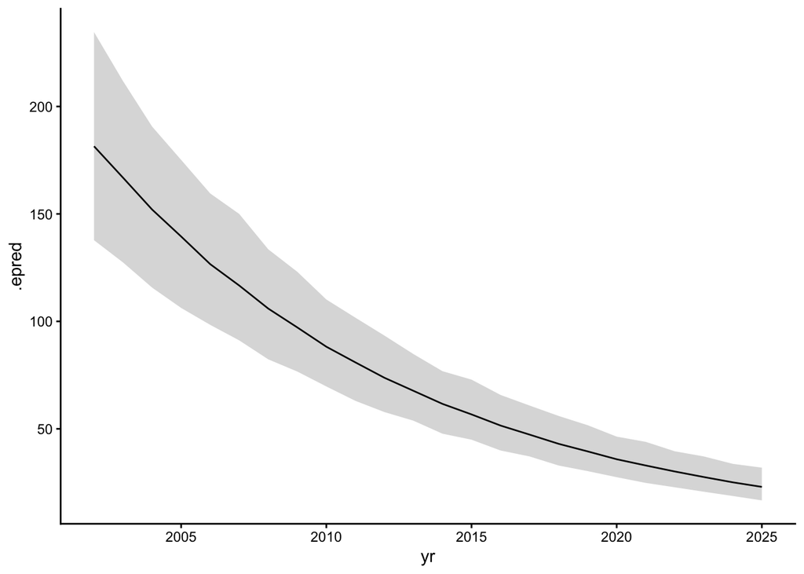

```r
tt <- colSums(tapmised[,-1]) %>% as.data.frame() %>% rownames_to_column()
colnames(tt) <- c("yr", "events")
tt <- tt %>% mutate(yr = parse_number(yr))

#get_prior(formula = events~ yr + ar(yr, p=1), tt, family = poisson())
priors <- c(
  prior("normal(0, 10)", class = "ar"),
  prior("normal(0, 10)", class = "b")
)
m_ar1 <- brm(
  formula = events~ yr + ar(yr, p=1, cov = TRUE),
  data = tt,
  family = poisson(),
  prior = priors,
  chains = 3,
  file = "models/m_ar1",
  #file_refit = "on_change",
  save_pars = save_pars(all = TRUE)
)

tibble(yr = seq(from = 2002, to = 2025)) %>%
  tidybayes::add_epred_draws(m_ar1) %>%
  tidybayes::mean_qi(.epred) %>%
  ggplot(aes(yr, .epred)) +
  geom_line() +
  geom_ribbon(aes(ymin = .lower, ymax = .upper), alpha = 1/5) +
  theme_classic()
```

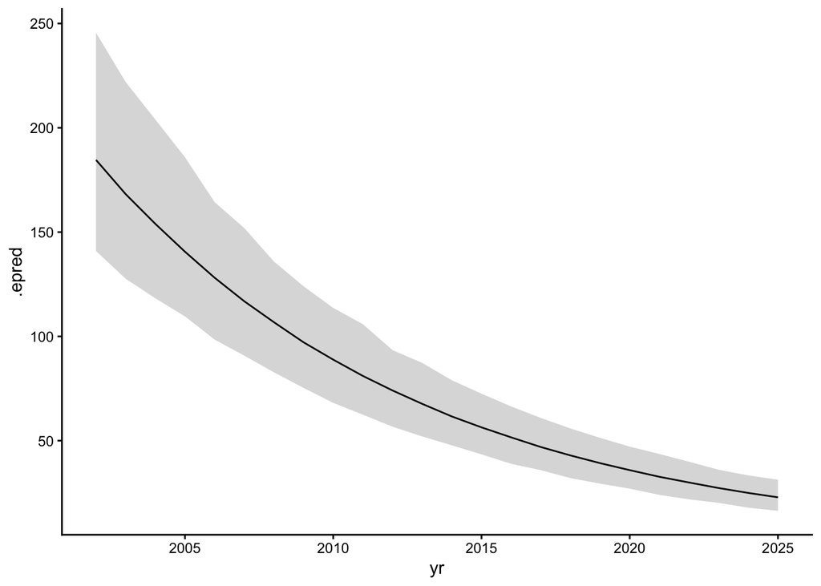

```r
#get_prior(formula = events~ yr + arma(yr, p=1), tt, family = poisson())
priors <- c(
  prior("normal(0, 10)", class = "ar"),
  prior("normal(0, 10)", class = "b"),
  prior("normal(0, 10", class ="ma")
)
m_arma1 <- brm(
  formula = events~ yr + arma(yr, p=1, q=1, cov = TRUE), tt, family = poisson(),
  prior = priors,
  chains = 3,
  file = "models/m_arma1",
  #file_refit = "on_change",
  save_pars = save_pars(all = TRUE)
)

tibble(yr = seq(from = 2002, to = 2025)) %>%
  tidybayes::add_epred_draws(m_arma1) %>%
  tidybayes::mean_qi(.epred) %>%
  ggplot(aes(yr, .epred)) +
  geom_line() +
  geom_ribbon(aes(ymin = .lower, ymax = .upper), alpha = 1/5) +
  theme_classic()
```

## 7.6. Overdispersed count models

When counts arise from a mixture of different Poisson or binomial processes, there will be thicker tails than in pure distributions. This is called over-dispersion (the variance of a variable is its dispersion). For a counting process, the variance is a function of the same parameters as the expected value. For example, the expected value of a binomial is Np and its variance is Np(1 - p). When, after conditioning on the predictors, the observed variance exceeds this amount, then an omitted variable is producing additional dispersion in the observed counts. Thus, ignoring over-dispersion leads to the same problems as ignoring a predictor variable (confounding, masking true effects).

## Negative-binomial or gamma-Poisson.

A negative-binomial likelihood, also known as gamma-Poisson, assumes that each Poisson count observation has its own rate. It estimates the shape of the gamma distribution to describe the Poisson rates across cases. We assume that each event has its own rate or $\lambda$. The distribution of these lambdas is described by the Gamma distribution. So, the gamma distribution does not describe our data, but the rate parameters of N Poisson distributions, which we assume made our N data points.

`dgamma()` allows 2 parametrizations: shape (alpha)/rate (beta), and shape (alpha)/scale (1/alpha) where scale = 1/shape. As a third parametrization there is mean (mu)/shape (alpha).

In brms this is the model:

$$y_i \sim GammaPois(\mu, \alpha)$$

$$log(\mu) = \beta_0$$

Where $\mu$ takes the place of $\lambda$ for Poisson distribution. After fitting the model, the intercept (mu) should be back-transformed as $exp(mu)$. The shape parameter is assigned a `gamma(0.01, 0.01)` prior by brms, based on shape/rate ($\alpha$, $\theta$).

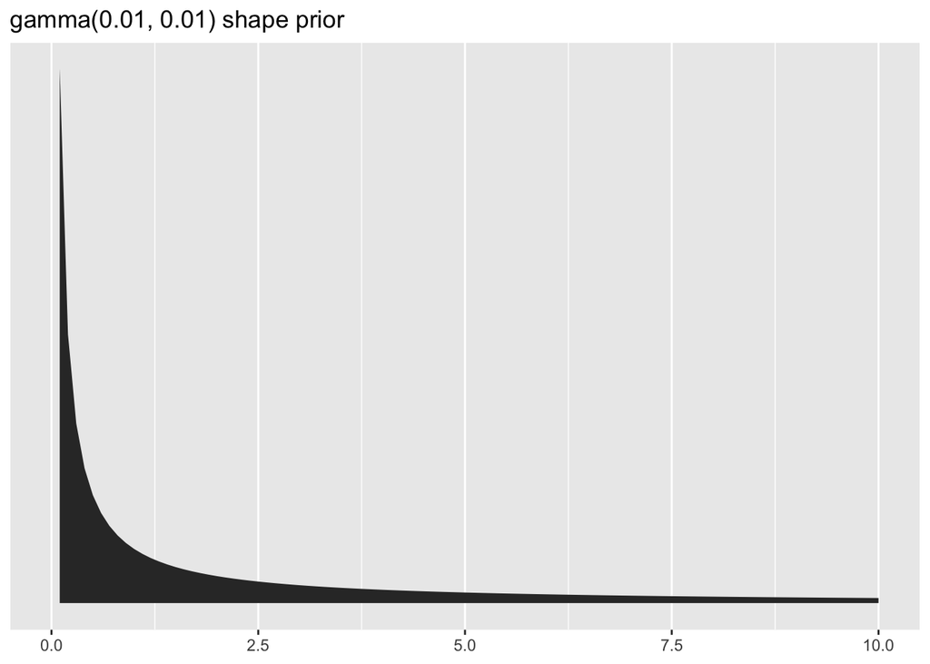

Brms family is `family = negbinomial` where mu is log-linked.

To use alpha (shape) and mu parameters estimates to visualize the model-implied gamma distribution of lambdas, we have to transform the $\mu$ to theta (rate) like this: $\theta = \mu/\alpha$; base::dgamma() takes theta and alpha (the shape/rate parametrization).

## Beta distribution and beta-binomial distribution

### The Beta prior

Beta story: You wait for 2 Poisson processes to arrive. The individual steps of each process happen at the same rate, but the first multistep process requires $\alpha$ steps and the second requires $\beta$ steps. The fraction of the total waiting time taken by the first process is Beta distributed. $\alpha > 0$, $\beta > 0$, covers interval 0 to 1. This makes it a good prior on probability scale.

PDF:

$$Beta(y) = \frac{y^{\alpha - 1}(1 - y)^{\beta - 1}}{B(\alpha, \beta)}$$

where B stands for the Beta function, which computes a normalizing constant. The base::dbeta() takes $\alpha$ and $\beta$ as shape1 and shape2 parameters.

$$E(X) = \frac{\alpha}{\alpha + \beta}$$

$$SD(X) = \frac{\alpha \beta}{(\alpha + \beta)^2(\alpha + \beta + 1)}$$

The uniform distribution is a special case of Beta distribution with $\alpha = \beta = 1$.

If $\alpha = \beta = 0$, the PDF cannot be normalized. This is used as an improper prior (Haldane prior). If $\alpha = \beta = 0.5$, then we have the Jeffreys prior.

base::R

- dbeta(x, shape1, shape2, ncp = 0, log = FALSE)
- pbeta(q, shape1, shape2, ncp = 0, lower.tail = TRUE, log.p = FALSE)
- qbeta(p, shape1, shape2, ncp = 0, lower.tail = TRUE, log.p = FALSE)
- rbeta(n, shape1, shape2, ncp = 0)

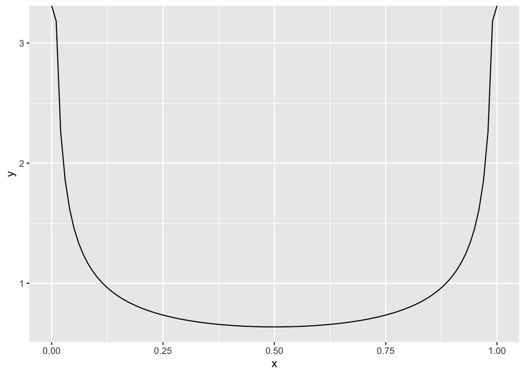

The Jeffreys horseshoe prior

[figure not shown]

```r
x <- seq(0,1, length.out = 100)
y <- dbeta(x, 0.5, 0.5)
ggplot(data=NULL, aes(x=x, y=y)) + geom_line()
```

The Haldane prior

```r
x <- seq(0,1, length.out = 100)
y <- dbeta(x, 0, 0)
ggplot(data=NULL, aes(x=x, y=y)) + geom_line()
```

If we give binomial likelihood a beta prior, the the peak of the posterior is at $\frac{\alpha + y}{\alpha + \beta + n}$ and it stays between the sample proportion $y/n$ and the E(X) of prior $\alpha /(\alpha + \beta)$. SD of posterior is given by $\sqrt{\frac{(\alpha + y)(\beta + n -y)}{(\alpha + \beta + n) ^2(\alpha + \beta + n +1)}}$ and it approximates normal, as n increases. This approximation to normal happens sooner, if we use the logit link for the probability: $log(p/(1-p))$.

```r
pbar  <- .4
theta <- 5
ggplot(data = tibble(x = seq(from = 0, to = 1, by = .01)),
       aes(x = x, y = rethinking::dbeta2(x, pbar, theta))) +

  geom_area()+ scale_y_continuous(NULL, breaks = NULL) +

  ggtitle("The Beta distribution",
          subtitle = expression("Defined in terms of "*mu*" (pbar) and "*kappa*" (theta)"))
```

[output not shown]

$$\phi = \frac{\alpha}{\alpha + \beta}$$

$$\kappa = \alpha + \beta$$

$$\alpha = \phi \kappa$$

$$\beta = (1 - \phi ) \kappa$$

$$\sigma = \sqrt{(\phi(1-\phi)/(\kappa +1))}$$

To get back to alpha and beta parametrization (code from the Kruschke textbook):

```r
betaABfromMeanKappa <- function(mean, kappa) {
  if (mean <= 0 | mean >= 1) stop("must have 0 < mean < 1")
  if (kappa <= 0) stop("kappa must be > 0")
  a <- mean * kappa
  b <- (1.0 - mean) * kappa
  return(list(a = a, b = b))
}

betaABfromMeanKappa(0.4, 5)
```

```
## $a
## [1] 2
##
## $b
## [1] 3
```

### The Beta-binomial likelihood

A beta-binomial model is a mixture of binomial distributions. It is not the same as Beta distribution. It assumes that each binomial count observation has its own probability of success. We estimate the distribution of probabilities of success (as a beta distribution), instead of a single probability of success. Any predictor variables describe the shape of this distribution.

$$y_i \sim BetaBin(n_i, \hat p_i, \phi)$$
$$logit(\hat p_i) = \alpha_{i}$$

Beta binomial has to be made a custom family in brms.

```r
beta_binomial2 <- custom_family(
  "beta_binomial2", dpars = c("mu", "phi"),
  links = c("logit", "log"), lb = c(NA, 2),
  type = "int", vars = "vint1[n]"
)

stan_funs <- "
  real beta_binomial2_lpmf(int y, real mu, real phi, int T) {
    return beta_binomial_lpmf(y | T, mu * phi, (1 - mu) * phi);
  }
  int beta_binomial2_rng(real mu, real phi, int T) {
    return beta_binomial_rng(T, mu * phi, (1 - mu) * phi);
  }
"

stanvars <- stanvar(scode = stan_funs, block = "functions")
```

Instead using the $y \vert trials() \sim$ , we are replacing `trials()` with `vint()`, which can only be used in custom families.

## Zero-inflated models

the zero-inflated Poisson

$$y_i \sim ZIPoisson(p_i, \lambda_i)$$
$$logit(p_i)= \alpha_p + \beta_p x_i$$
$$log(\lambda_i)=\alpha_{\lambda} + \beta_{\lambda} x_i$$
where both parameters in the likelihood get their own statistical model. In brms, $p_i$ is denoted $zi$. `family = zero_inflated_poisson`. To use a non-default (beta) prior for zi, indicate `class = zi` within `prior()`. zi is presented in the probability scale, unless there are predictors for zi in the model (while mu is always in the log-scale).

The `tidybayes::parse_dist()` takes the kind of string specifications you include in the `brms::prior()` and converts them into a format one can plot with.

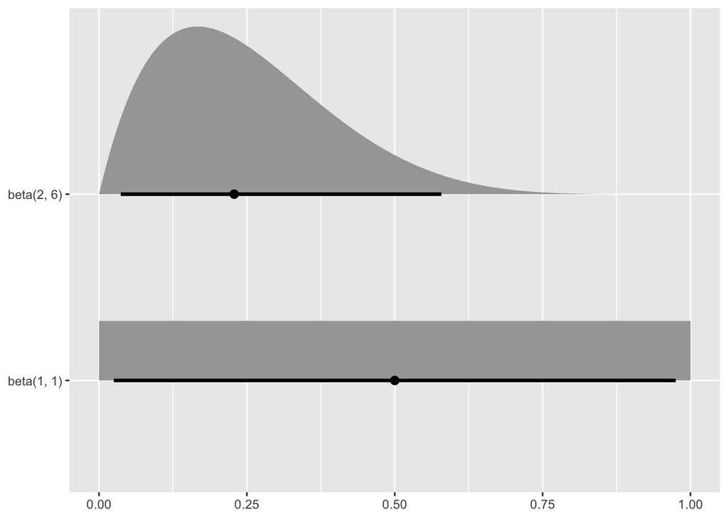

```r
priors <-
  c(prior(beta(1, 1), class = zi),

    prior(beta(2, 6), class = zi))

priors %>% tidybayes::parse_dist(prior) %>%

  ggplot(aes(y = prior, dist = .dist, args = .args))+

  tidybayes::stat_dist_halfeye(.width = .95)+

  ylab(NULL)+ xlab(NULL)+ theme(legend.position = "none")
```

# Appendix: Statistical Best Practices

The following should be taken as recommendations, at your own responsibility. Statistics is complicated and most often there is no single best way of doing it. Neither is there a single correct answer.

## Data structure

For analysis in R often the tidy format is best for plotting data in ggplot.

Tidy data: each row is an object of measurement (what is measured) and each column is a single variable that is measured. Different types of objects of measurement (mouse, human) go into separate tables. If there are several measurements per object of measurement (time points, etc), then there are several rows for every object of measurement, and a separate ID variable.

```r
tribble(~ID, ~age, ~cholesterol, ~weight, ~sex,
        "A",  67, 180, 87, "M",
        "A",  68, 167, 87, "M",
        "B",  56, 162, 72, "F",
        "B",  57, 176, 72, "F") %>% kable()
```

| ID | age | cholesterol | weight | sex |
| --- | --- | --- | --- | --- |
| A | 67 | 180 | 87 | M |
| A | 68 | 167 | 87 | M |
| B | 56 | 162 | 72 | F |
| B | 57 | 176 | 72 | F |

In this table we have 2 objects of measurement (2 people), A and B, both have given 2 cholesterol measurements a year apart, plus there are weight data that have been measured once and data on the sex (male or female). This is tidy data, which is optimized for visualization with ggplot2.

For biological data, other formats are often required for compatibility with specialized analysis packages.

## EDA - exploratory data analysis

The goal is to check for general features of data (range, variation, distribution), as well as surprising and alarming features, like impossible values and other outliers. But also check possible co-dependencies in data by looking at co-variation between 2 or more variables. So EDA checks the data quality (and by this, the quality of the experiment and/or data collection), but it also tries to form a first impression about anything scientifically interesting in the data. EDA aslo gives hints about possible routes for data pre-processing for formal modeling.

Always start your analysis by plotting out the data, and simple dependencies. Never start by formal modeling of the data.

**Visulizations of one-dimensional continuous data in the order or increasing information loss:**

1. strip chart plots out single datapoints in one-dimensional data (a single variable). No information loss.

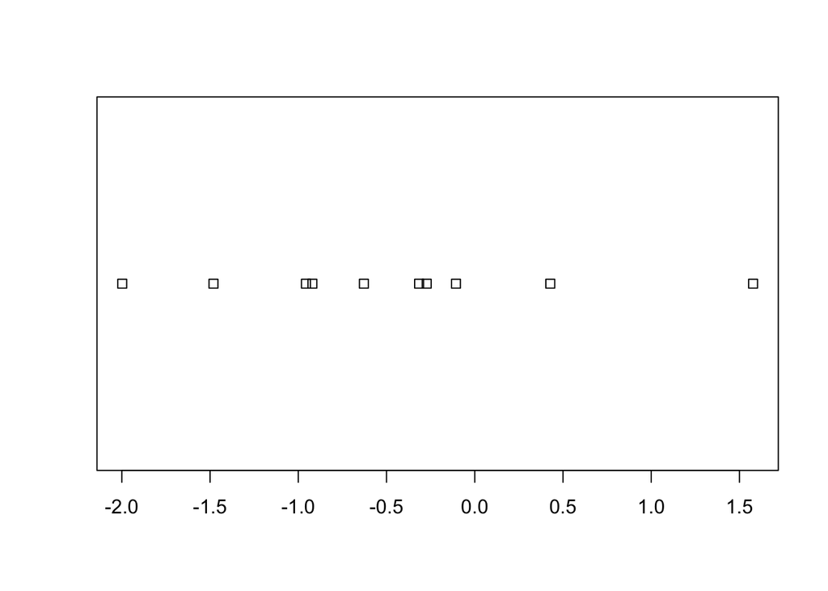

A strip chart of normal data, n=10

2. histogram plots out single-dimensional data with loss of information. The shape of the histogram depends on arbitrarily set bin width. Therefore, it is often a good idea to try different binwidths and see, what happens.

two histograms of normal data, n=10 and n=100 (red)

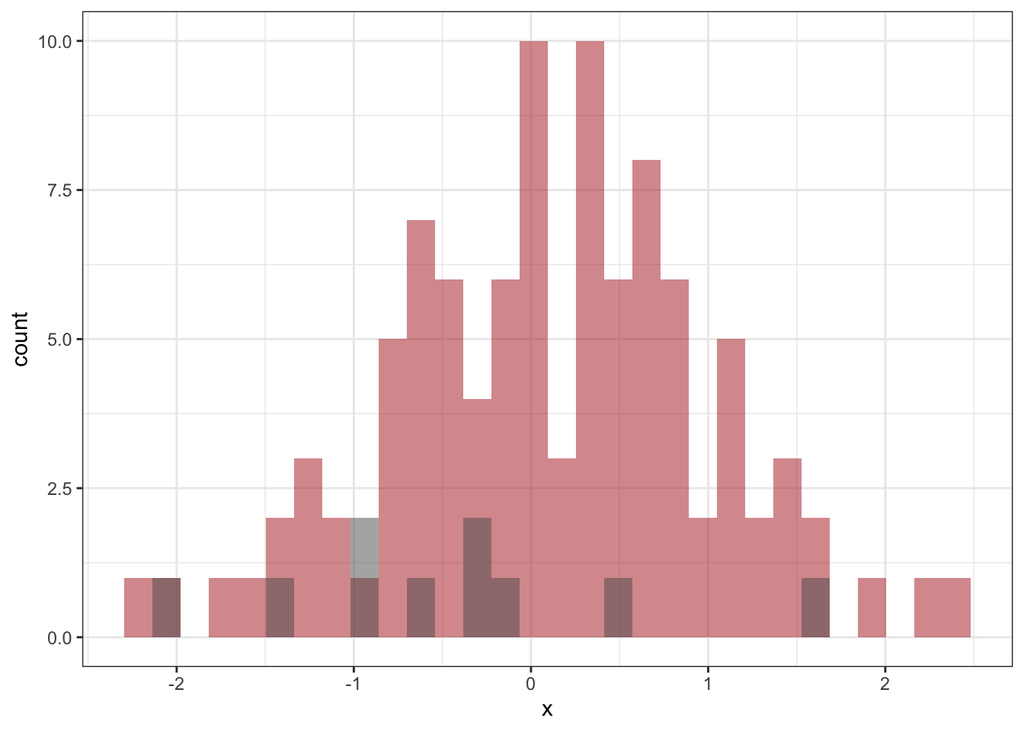

3. density plot is a smoothed histogram whose y-axis is normalized into probability scale. The area under the density plot equals one. Violin plot is another form of density plot.

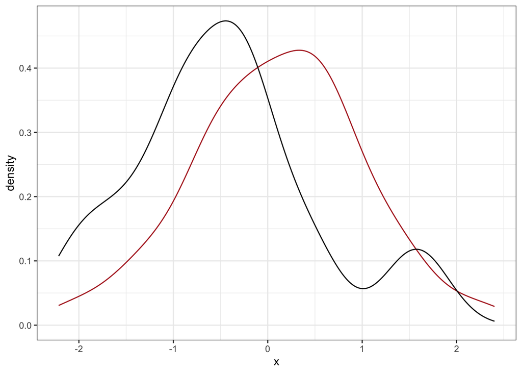

density plots of same data as before

**For comparisons of several continuous data distributions:**

1. Individual data points with medians (preferable) and/or means, shown as bars. This should be your default representation when neither the sample size n or the number of comparison k is not large. For n < 10 and k < 10, this is nearly always the best option. There is no information loss! Also, it is possible to superimpose standard deviation/standard errors/confidence intervals.
2. For at least moderately large n (>30, say) and small k (2-4, say), superimposed histograms or density plots are a good choice.
3. For at least moderately large n and moderate k (10-30, say), violin plots do the trick

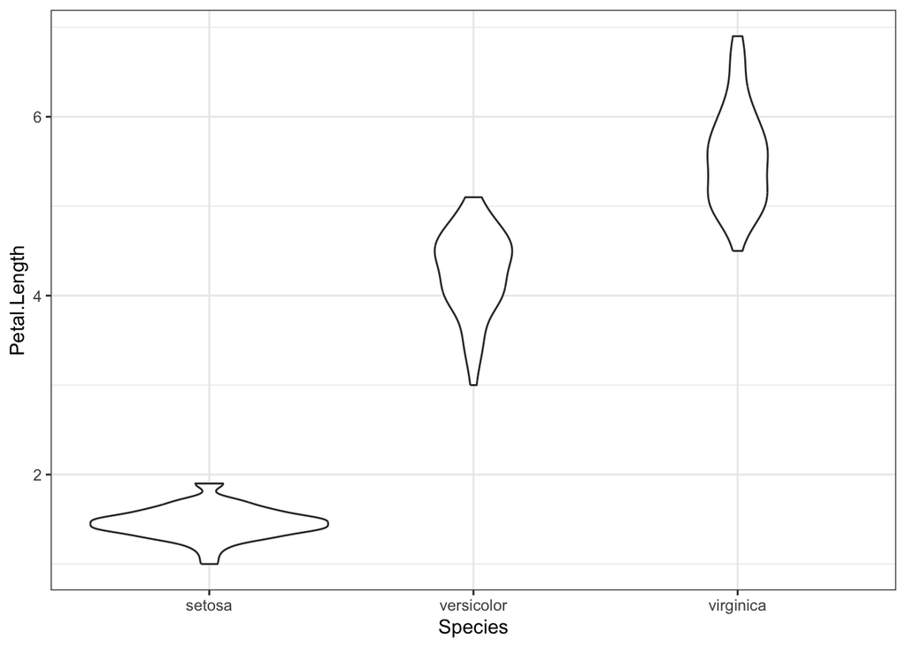

violin plot of iris data

4. For at least moderately large n and fairly large k (20 - 50, say), consider box plots. Box plot presents the median, 25% and 75% quantiles and (typically) whiskers that strech for 1.5 times interquartile range (until the last datapoint that falls inside 1.5xIQR). Datapoints outside 1.5 x IQR are shown separately as outliers. Box plots lead to largest information loss, but can be a good option, if one wants to show many distributions (many variables) side-by-side.

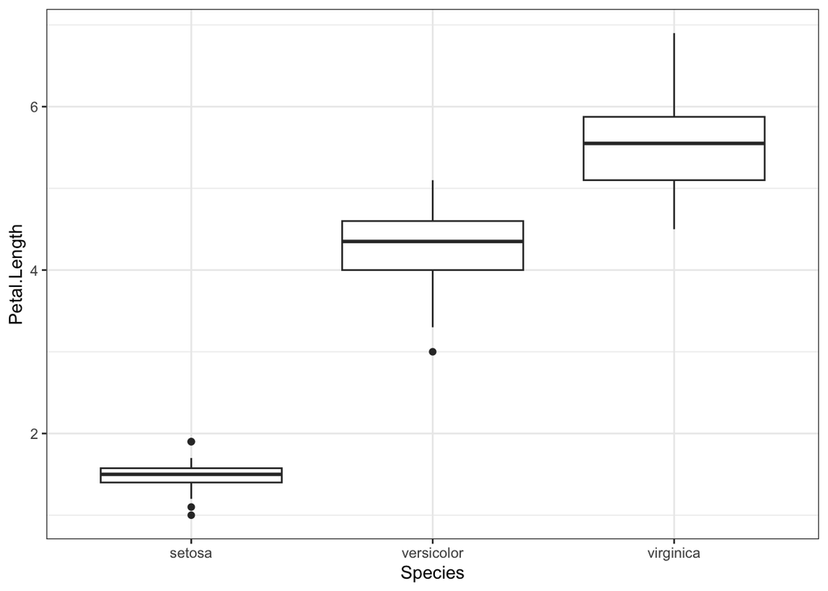

box plot of iris data

5. For at least moderately large n and large k (>30), consider joy plots, a.k.a. ridge plots.

A joy plot of fuel consumption of cars of different producers and drives. Individual cars are shown as ticks.

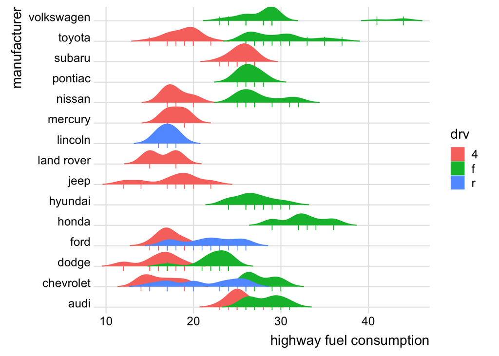

**For examining co-variation in continuous data:**

scatter plot of 2 measured variables of 3 Iris species. Each point corresponds to an individual plant. Point size indicates sepal lenght of the plant and opacity indicates sepal width.

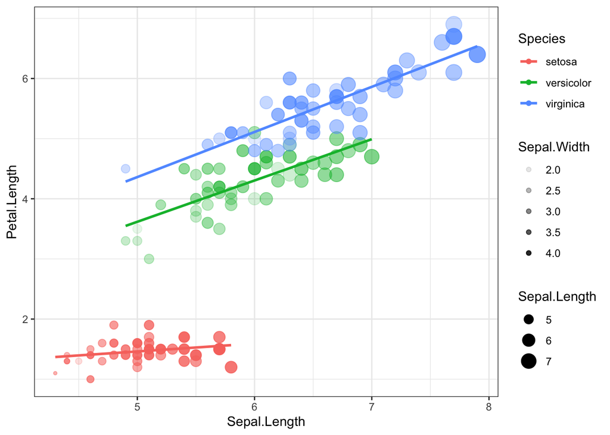

To plot more than about 4 dimensions of data, consider using dimension reduction techniques, like principal component analysis (PCA) and its relatives (tSNE for large datasets with non-linear dependencies, for example). When you do use them, understand that they are harder to interpret and can be seriously misleading. Dimension reduction requires great care and detailed knowledge about the assumptions behind each technique.

> A psychological note: Human cognition is good in accurately perceiving differences in bar lengths that are anchored at a common starting point. We are lousy in perceiving differences in areas, in angles, and in color saturation/intensity. So avoid, as much as you can, comparisons through circle diameter or area (in addition, in published work these are usually not differentiated to the reader).

### What to do and what not to do in plotting data for publication.

While EDA you are doing for your own consumption, data is also plotted for publications, and there the goal is not to find new stories, but to present the ones that you have already made up. Such figures are presented to further the storytelling. This means that graphs are no longer neutral, but try to convince the reader of the validity of a made-up story. Like an official photograph of a sex symbol, graphs can be deceptive!

1. Do not use pie charts to show proportions of a whole. In fact, never use pie charts at all. To visualize proportions, use bar plots in the range 0…1.
2. For continuous variables, consider avoiding bar plots. Just plotting the means as dots or line segments is often visually better. Then its also easier to include individual data points
3. When the x-axis is continuous, prefer line plots. If intermediate points on the x axis between the measured points are scienifically possible, use the line graph, rather than bar plots.
4. Be careful with plots with two distinct y-axes. They are controversial and can often deceive. Use of two y-axes is not controversial, when the two axes are transformations of each other (like Fahrenheit and Celsius).
5. Remember that by choosing the ranges of y axis (but also the x-axis) you can make the effects seem larger or smaller to human perception. Even the aspect ratio of the graph can make a great difference in terms of perceived slopes. Use this power responsibly!
6. Do not superimpose straight lines over non-linear associations. Use loess-lines instead (like the geom_smooth function with default settings).

In general, when making publication-quality graphs pay attention to how much of the ink in the graph is actually showing data (like lines, dots, *et al*.), versus other elements of the graph (like borders, shading, axes with their ticks and whatnot). You want this ratio to be rather large. Avoid focusing readers to elements of the graph that are not directly needed for understanding the data. For this reason a sucessful black-and-white graph is better than one in grayscale, which in turn is better than a colour graph. In the end, your goal is to make the reader understand, what you want to say with a graph, in a shortest possible time. Of course, this does not mean that graphs cannot be complicated and take a long time to ingest. They can, if you do not have a better choice.

## Data summaries

If you are graphing individual datapoints, then summarising the data by the median (which is also graphed) is the safest bet, because the mean (arithmetic mean) becomes hard to interpret for non-symmetrical data distributions. The median always has the same interpretation as the data point, from which half the data is larger and half is smaller.

The most likely datapoint is not the median, but the mode. The mode is often harder to estimate with any precision than the median or the mean. The mean is more efficient than the mode or the median, in the sense that one can build narrower confidence intervals around the mean than the median. But this does not change the fact that median often makes more intuitive sense. In fact it is hard to imagine a situation in biology (although not in economy) where the mean makes better conceptual sense than the median.

For log-normally distributed data (and a lot of biological data are log-normal) the geometric mean carries the same meaning in the original scale as the arithmetic mean in the logarithmic scale. The geometric mean should be accompanied with multiplicative standard errors.

> For description of central tendency use mean for symmetrical distributions, but the median for most datasets you come accross.

For summarising data variation the most common measure is standard deviation (SD). SD is defined conditionally on data distribution. For most distributional models used in biology one can calculate the interval, which encompasses 68% of the area under the peak. 1.96 SD-s cover 95% of the area under the peak. This interval is the SD. So, for normal, lognormal and many other distributions there are different algorithms that give you the SD. The usual equation for SD that is thaught at shool applies for the normal distribution.

A close relative of the SD is the **S**tandard **E**rror of the **M**ean (SEM). When we take a random sample sized n from a population then 68% of its individual datapoints fall within the interval $mean +/- SD$. But when we take many such samples with size n, and calculate the mean for each one of them, then 68% of these means fall within the interval SD divided by square root of n (centered on the mean of the means, or the combined mean of all the samples). This new measure $\sqrt n$ is the SEM, which is a measure of our uncertainty about our estimate of the mean. If n is large, then 1SEM = 68% CI, 1.96SEM = 95% CI and 3SEM = 99% CI. In biology, n is ususally not large enough for this simple conversion; also note that, even with large n, presenting on your figures 68% CI-s is probably not what you really want to do.

SEM is sometimes called the “SD of the mean”.

An alternative to SD is the MAD - the median absolute deviation. If SD is normally calculated as
$$SD = \sqrt{\frac{\sum(x_i - \hat x)^2}{n-1}}$$

then mad is
$$MAD = \frac{\sum\vert x_i - \hat x \vert}{n}$$

The MAD is both more intuitive and less sensitive to outliers (note the lack of the squaring operator). However, it does not have the neat mathematical properties of the SD (remeber the SEM and the CI).

As a convention, mean and SD should be used together, as median and MAD should be used together.

Another useful summary of data variation is the interquartile range (IQR). This is usually geven as 5 numbers: the minimum value – 25th percentile – median – 75th percentile – maximum value. So the IQR really covers half of the data around the median (this is exactly what the box in a boxplot does).

Beware of summarising data via min and max, as these depend on sample size. The more data you have, the further min and max tend to creep from the median. For the same reason, beware of estimating population distribution from the shape of the data distribution, as even highly non-symmetric distributions can appear near-normal with moderate sample sizes. Statistical normality tests should therefore be avoided (especially as with large n-s they always provide small p values, suggesting non-normality even with approximately normal data).

## Confidence intervals

- SD-s show data level variation. As a rule, you should not put SD on a graph with data points shown (because it does not add much). Rather use it in text like this: mean (SD).
- SEM indicates uncertainty around your estimate of the mean, but it should not be put on a figure or directly interpreted.
- 95% CI means (in its Bayesian interpretation) that you are 95% certain that the true population mean lies within this interval.

  Frequentist CI have a different, and arcane, interpretation, but they are nevertheless often numerically similar to the Bayesian CI (and when not, Bayesian CI usually wins).

> A p value of 0.05 means that the 95% frequentist CI just barely touches the zero effect (assuming that $H_0$ is defined as a zero effect). Likewise, p = 0.11 means that the 89% CI touches the zero effect.
- If you want to show uncertainty around your estimate of the mean, use CI for the mean. If you want to show uncertainty around your estimate of the effect size (mean1 - mean2), then show the CI for the effect, not two CI-s for each mean!
- There are continuous CI-s that look like this.

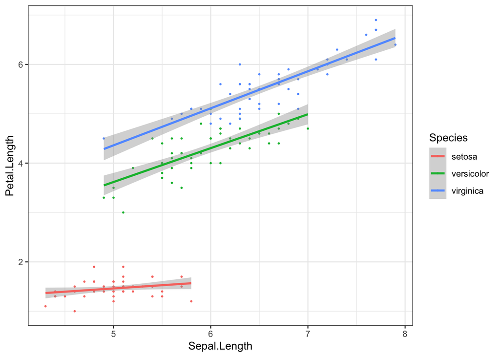

Continuous CI-s or confidence regions

- Do not use discrete CI-s where you can model continiuous ones, as the discrete ones are less efficient and harder to interpret.

You can estimate the difference of slopes with 95% credible intervals like this:

```r
m_setosa <- brm(Petal.Length~Sepal.Length,
                data=iris %>% filter(Species == "setosa") ,
                file = "models/m_setosa")
m_versicolor <- brm(Petal.Length~Sepal.Length,
                    data=iris %>% filter(Species == "versicolor") ,
                    file = "models/m_versicolor")
posterior_setosa <- posterior_samples(m_setosa)
posterior_versicolor <- posterior_samples(m_versicolor)
posterior_summary(posterior_setosa$b_Sepal.Length - posterior_versicolor$b_Sepal.Length)
```

```
##        Estimate Est.Error       Q2.5      Q97.5
## [1,] -0.5547548 0.1124594 -0.7798023 -0.3396564
```

So any change in sepal length is predicted to have a smaller effect on petal length in *I. setosa* than it does in *I. versicolor*. This difference is somwhere between 0.3 and 0.8 units. This is quite a large difference in slopes (their absolute values being in the same range).

```r
posterior_summary(posterior_setosa$b_Sepal.Length)
```

```
##       Estimate  Est.Error        Q2.5     Q97.5
## [1,] 0.1325976 0.07122992 -0.00966488 0.2738349
```

```r
posterior_summary(posterior_versicolor$b_Sepal.Length)
```

```
##       Estimate  Est.Error      Q2.5     Q97.5
## [1,] 0.6873524 0.08905853 0.5110829 0.8595665
```

## P values and statistical significance

> P value is the probability of encountering your sample data or more extreme data, if we suppose that there really is no effect.

P value is in the probability scale (0…1) and it tries in effect to answer the question of how likely it is to see data like yours, assuming that there is actually no true effect. A large p value can be seen as a warning that your sample effect migth well be a random sampling error, which is not indicative of a “real” effect. Sample error is not the only possible explanation for a large p value, but as it is so very pertinent to interpreting ones results scientifically, it can rarely be ignored. A small p value is different in that while it can also mean several things, its much harder to convert into action. P value says nothing about the likelihood that the effect, which you see, might be bias and it says pretty much nothing about the actual size of your effect. Most importantly, p value does not give the probability that there is no effect (that the null hypothesis is true), and neither gives it the probability that some scientifically interesting hypothesis is true or false. Thus the direct interpretative use of raw p value is quite limited.

It can mean a large sample size, a low variation, a large true effect, or a large bias.

**Statistical significance** is a concept that uses p values as input and actually does convert small p values into action. >If your p value is less than some arbitrary value, like 0.05, and if you then claim that your result is “statistical significant”, then in the long run 5% of experiments with zero true effects are classified as “significant”.

The interpretation of “significance” is (i) over the long run, rather than about a specific experiment, and (ii) it depends on the fraction of true null experiments (the ones with zero effect) from all experiments that were done.

**The multiple testing problem** – If you do over some time or experimental system or field of study k independent tests of k independent samples, and call all tests, whose p<0.05 “significant”, then $p_{corrected} = p/k$. This is the Bonferroni correction, which fixes the familiy-wise type I error rate at the level p. Presenting any results whose p/k < 0.05 as “significant” has the same meaning as presenting a p value from a single test, whose p < 0.05 as “significant”. Thus we fix the familiy-wise type I error rate at the level p. Unfortunately, this correction leads to a serious loss of sensitivity (it increases the frequency of type II errors). To mitigate this problem, a host of compromise procedures, like sequential Bonferroni, has been developed. These corrections result in a higher corrected p value, which no longer fixes the type I error level at 0.05, but lead to a smaller drop in sensitivity. Maybe the most serious aspect of the multiple testing problem is that there is no consensus about what constitutes a family of tests. It could be multiple tests done within a single experiment (like measuring the level of 20 000 mRNAs from a sample of 3 biological samples), or all experiment done by you over your lifetime, or all experiments done by various groups within the confines of a single well-defined experimental system, or whatever. Perhaps the best recommendation that can be given is to record and publish all calculated p values. But even this is far from enough, as it has been sucessfully argued that not only the tests that were done, but also those that would have been done, had data been different, count in the family k.

Multiple testing problem presents a very strong argument for abandoning the very concept of “statistical significance” as unworkable in scientific practice. The alternative approach entails Bayesian estimation of sample means and effect sizes, accompanied by measures of estimation uncertainty, which are often presented in the form of 95% credible intervals. Within this approach false alarms are dealt by the prior structures and by using multi-level modeling.

There are also frequentist confidence intervals, which are mathematically consistent with p values (a 95% CI can be defined as a range of non-significant p values, which treat the sample mean as the null hypothesis). These intervals should also corrected for multiple testing, so in this respect they have no advantage over the p value.

Currently, the almost only sensible use of p values would be experiments that do at least hundreds of parallel measurements of each sample (that is, omics experiments in biomedicine). Then we can use the p values as input for checking the quality of the experiment (by p value distribution), to calculate the fraction of true null effects (using the shape of the p histogram), to calculate individual q values, and even the prospective power of the experiment. The idea here is not to actually interpret p values, but to use them as input to further calculations, which might result in better interpretable statistics.

> if a p value indicates P(data I H0), then a corresponding q value indicates P(H0 I data).

> A q value estimates the probability that the effect is exactly zero, if we see sample data that is similar to your data. Its still a mouthfull, but is at least getting closer to what one might want from a statistic. Each q value is calculated, using the Bayes theorem, from the corresponding p value and the estimated fraction of true nulls, which in turn is calculated from all the p values in the experiment (we need at least hundreds of them).

# Appendix 2: brms code

```r
library(tidyverse)
library(here)
library(brms)
library(bayesplot)
library(tidybayes)
library(modelr)
#library(rethinking)
library(rstan)
rstan_options(auto_write = TRUE)
options(mc.cores = parallel::detectCores())
```

Loading WaffleDivorce data from rethinking package.

```r
(waffledivorce <- read_csv2(here("data/waffledivorce.csv")))
```

```
## ℹ Using "','" as decimal and "'.'" as grouping mark. Use `read_delim()` for more control.
```

```
## # A tibble: 50 × 13
##    Location    Loc   Population MedianAgeMarriage Marriage `Marriage SE` Divorce
##    <chr>       <chr> <chr>                  <dbl>    <dbl> <chr>           <dbl>
##  1 Alabama     AL    4.78                     253      202 1.27              127
##  2 Alaska      AK    0.71                     252      260 2.93              125
##  3 Arizona     AZ    6.33                     258      203 0.98              108
##  4 Arkansas    AR    2.92                     243      264 1.70              135
##  5 California  CA    37.25                    268      191 0.39               80
##  6 Colorado    CO    5.03                     257      235 1.24              116
##  7 Connecticut CT    3.57                     276      171 1.06               67
##  8 Delaware    DE    0.90                     266      231 2.89               89
##  9 District o… DC    0.60                     297      177 2.53               63
## 10 Florida     FL    18.80                    264      170 0.58               85
## # ℹ 40 more rows
## # ℹ 6 more variables: `Divorce SE` <chr>, WaffleHouses <dbl>, South <dbl>,
## #   Slaves1860 <dbl>, Population1860 <dbl>, PropSlaves1860 <chr>
```

Let’s calculate summary stats from non-scaled data:

```r
waffledivorce %>%
  mutate_at("MedianAgeMarriage", ~.x / 10) %>%
  summarise_at(
    c("Marriage", "Divorce", "MedianAgeMarriage"),
    list(median = median, sd = sd)
    )
```

```
## # A tibble: 1 × 6
##   Marriage_median Divorce_median MedianAgeMarriage_median Marriage_sd Divorce_sd
##             <dbl>          <dbl>                    <dbl>       <dbl>      <dbl>
## 1             197           97.5                     25.9        38.0       18.2
## # ℹ 1 more variable: MedianAgeMarriage_sd <dbl>
```

We are using `standardize` function from **rethinking** package as it returns vector in contrast to `scale` function. `standardize` is a wrapper around `scale` anyway and keeping matrices in our tibbles causes trouble for some downstream functions.

```r
divorce <- waffledivorce %>%
  select(Loc, Marriage, Divorce, MedianAgeMarriage) %>%
  mutate_at(c("Marriage", "Divorce", "MedianAgeMarriage"), standardize)
```

Here we specify our model by using priors from non-scaled original data.

$$D_i \sim \text{Normal}(\mu, \sigma)\quad\text{[likelihood]}$$
$$\mu_i = \alpha + \beta M_i\quad\text{[linear model]}$$
$$\alpha \sim \text{Normal}(97.5, 18.5)\quad[\alpha\ \text{prior}]$$
$$\beta \sim \text{Normal}(0, 2.5)\quad[\beta\ \text{prior}]$$
$$\sigma \sim \text{Normal}(0, 18.5)\quad[\sigma\ \text{prior}]$$

- *D* denotes divorce rate.
- The predictor variable *M* is the marriage rate.

by default, **brms** provides **flat** priors for beta coefficients, so minimally we should provide these.

```r
get_prior(formula = Divorce ~ Marriage, data = divorce, family = gaussian())
```

```
##                 prior     class     coef group resp dpar nlpar lb ub tag
##                (flat)         b
##                (flat)         b Marriage
##  student_t(3, 0, 2.5) Intercept
##  student_t(3, 0, 2.5)     sigma                                 0
##        source
##       default
##  (vectorized)
##       default
##       default
```

First, we can test if our prior choice is reasonable by sampling only from prior:

Exercise, please choose your (better than default) priors for Intercept, beta and sigma parameters using **scaled divorce** data and fit the model.

we run the model on priors-only:

```r
priors <- c(
  prior("normal(0, 0.2)", class = "Intercept"),
  prior("normal(0, 0.5)", class = "b"),
  prior("normal(0, 1)", class = "sigma")
)
mod4.0 <- brm(
  formula = Divorce ~ Marriage,
  data = divorce,
  family = gaussian(),
  prior = priors,
  chains = 3,
  file = here("models/mod4.0"),
  sample_prior = "only",
  file_refit = "on_change"
)
```

```
## Found more than one class "stanfit" in cache; using the first, from namespace 'rstan'
```

```
## Also defined by 'rethinking'
```

```
## Found more than one class "stanfit" in cache; using the first, from namespace 'rstan'
```

```
## Also defined by 'rethinking'
```

```
## Found more than one class "stanfit" in cache; using the first, from namespace 'rstan'
```

```
## Also defined by 'rethinking'
```

Run pp_check multiple times, to get impression of prior-only performance:

```r
pp_check(mod4.0)
```

```
## Using 10 posterior draws for ppc type 'dens_overlay' by default.
```

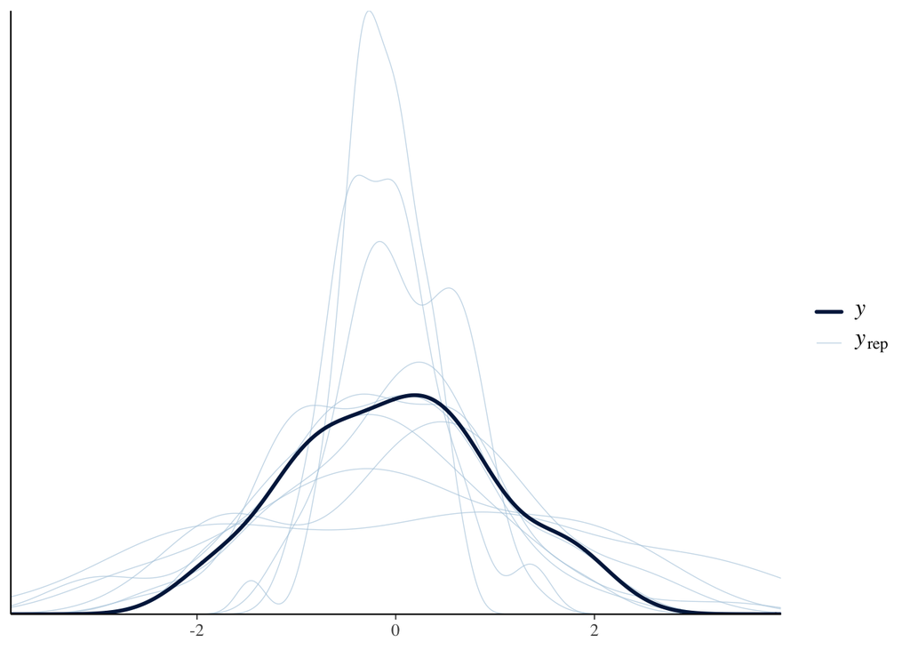

Let’s have a look how well our prior-only model recovers different distribution parameters

```r
y <- as.numeric(divorce$Divorce)
yrep <- posterior_predict(mod4.0)
```

We can check mean and max values in replications:

```r
ppc_stat(y, yrep, stat = "mean", binwidth = 1)
```

```
## Note: in most cases the default test statistic 'mean' is too weak to detect anything of interest.
```

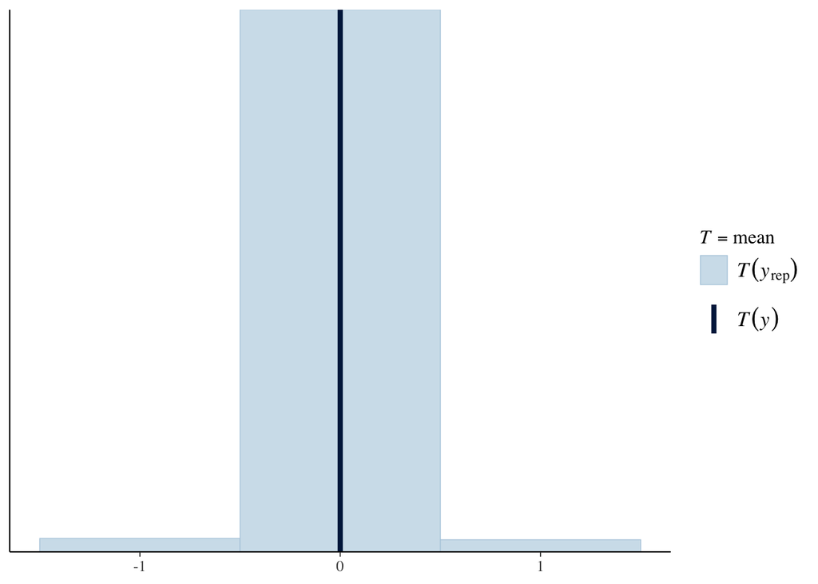

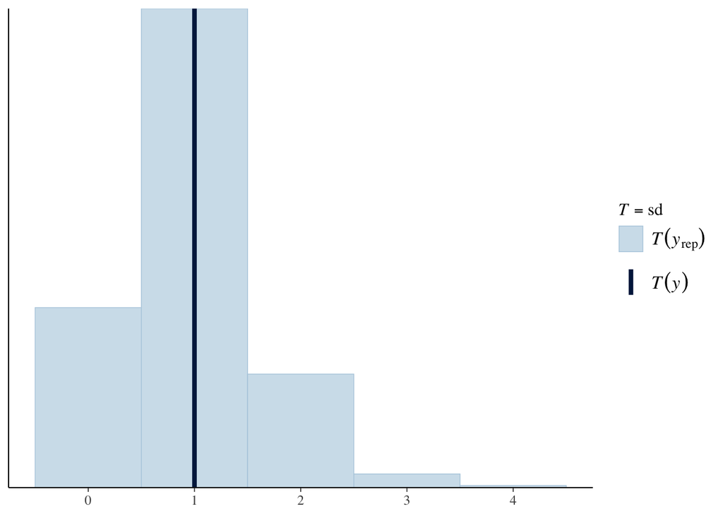

```r
ppc_stat(y, yrep, stat = "sd", binwidth = 1)
```

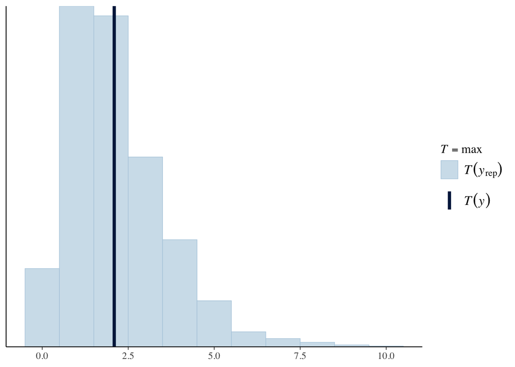

```r
ppc_stat(y, yrep, stat = "max", binwidth = 1)
```

Let’s visualize (keeping only small amount of samples to avoid over-plotting):

```r
samples4.0 <- as.data.frame(mod4.0) %>%
  slice_sample(n=50)
```

Here we can see a sample of plausible regression lines, based on our prior-only model:

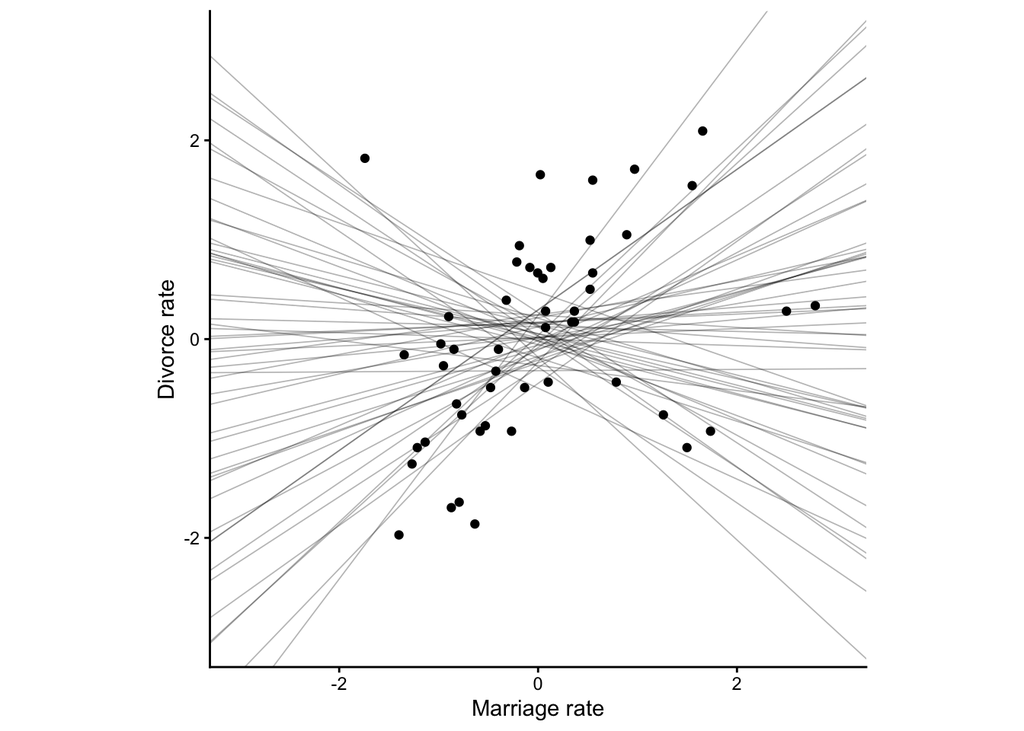

```r
ggplot() +
   geom_point(data = divorce, aes(Marriage, Divorce)) +
  geom_abline(data = samples4.0, aes(slope = b_Marriage, intercept = b_Intercept), size = 0.3, alpha = 0.3) +
  labs(x = "Marriage rate", y = "Divorce rate") +
  scale_x_continuous(limits = c(-3, 3)) +
  scale_y_continuous(limits = c(-3, 3)) +
  coord_fixed() +
  theme_classic()
```

Next, let’s sample fit model with data.

```r
priors <- c(
  prior("normal(0, 0.2)", class = "Intercept"),
  prior("normal(0, 0.5)", class = "b"),
  prior("normal(0, 1)", class = "sigma")
)
mod4.2 <- brm(
  formula = Divorce ~ Marriage,
  data = divorce,
  family = gaussian(),
  prior = priors,
  chains = 3,
  file = here("models/Divorce~Marriage"),
  sample_prior = "yes"
)
```

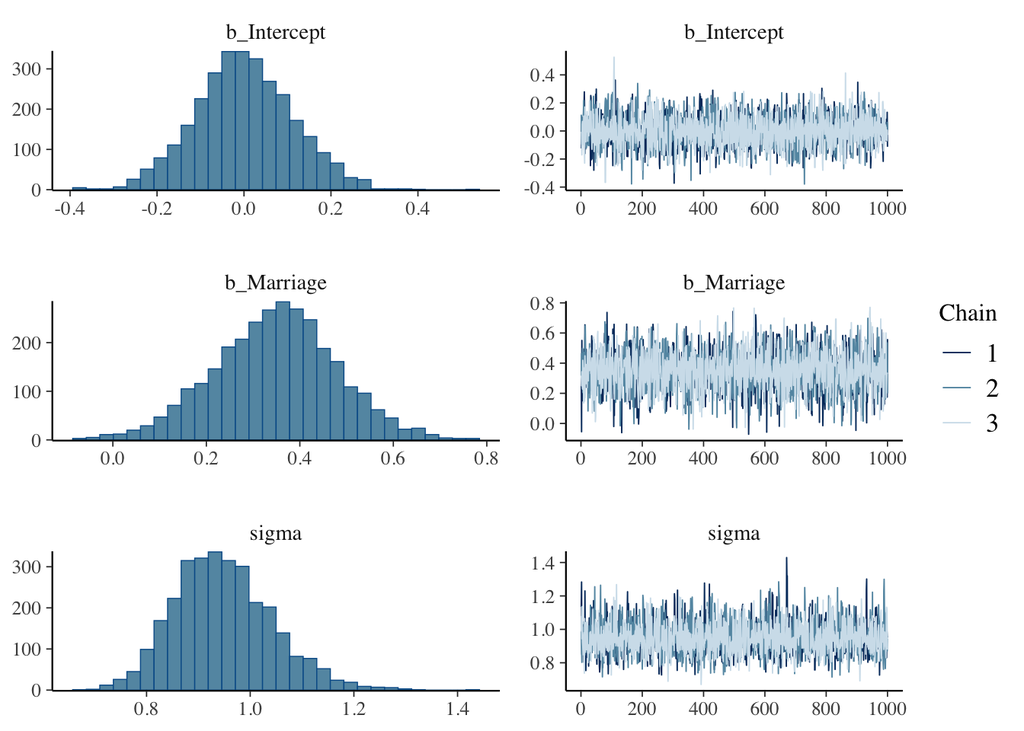

```r
plot(mod4.2)
```

Let’s add residuals and fitted values to our data:

[output not shown]

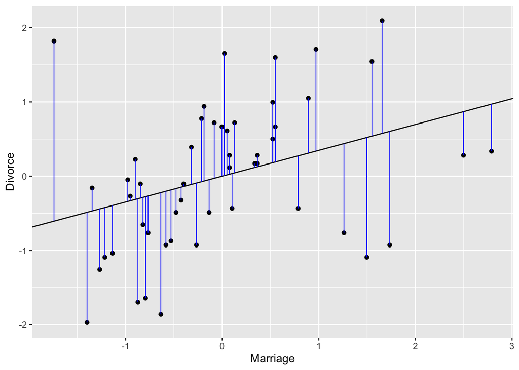

```r
(post_sum4.2 <- divorce %>%
   select(Marriage, Divorce) %>%
   add_epred_draws(mod4.2) %>%
   summarise_at(".epred", mean))
```

```r
coefs <- fixef(mod4.2)
post_sum4.2 %>%
  ggplot(aes(x = Marriage)) +
  geom_point(aes(y = Divorce)) +
  geom_abline(slope = coefs[2, 1], intercept = coefs[1, 1]) +
  geom_segment(aes(xend = Marriage, y = .epred, yend = Divorce), size = 1/3, color = "blue")
```

```
## Ignoring unknown labels:
## • fill : "NA"
## • colour : "NA"
## Ignoring unknown labels:
## • fill : "NA"
## • colour : "NA"
```

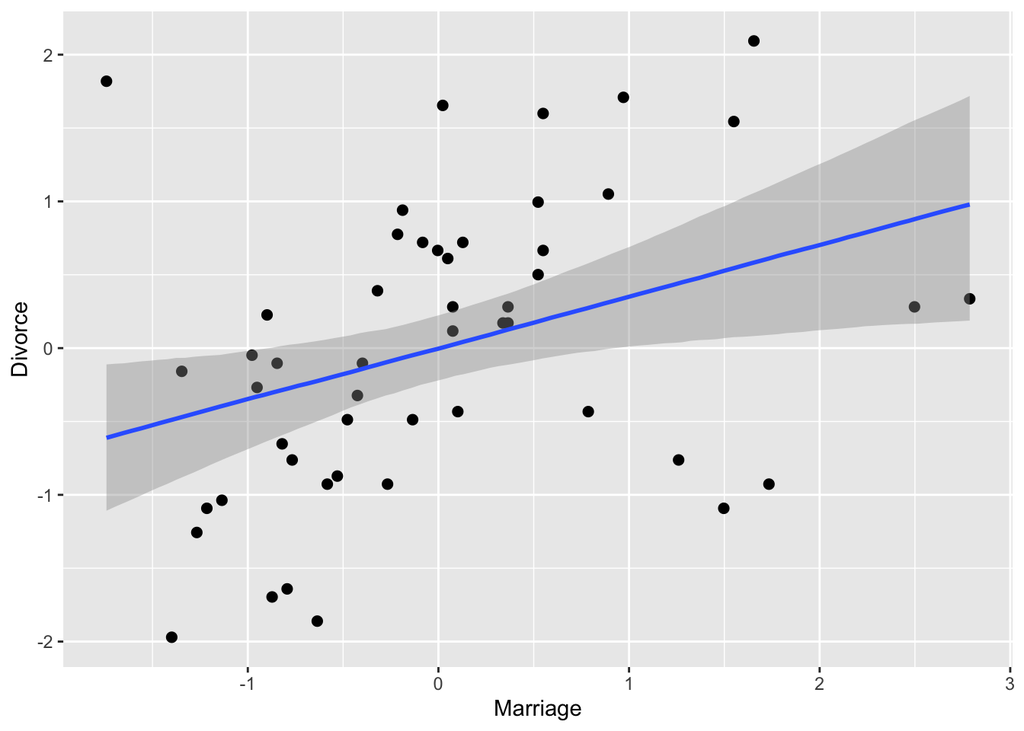

```r
plot(conditional_effects(mod4.2), points = TRUE, ask = FALSE)
```

We want to test one-sided hypothesis whether b_Marriage coefficient is bigger than 0.

```r
get_variables(mod4.2)
```

```
##  [1] "b_Intercept"     "b_Marriage"      "sigma"           "prior_Intercept"
##  [5] "prior_b"         "prior_sigma"     "lp__"            "accept_stat__"
##  [9] "stepsize__"      "treedepth__"     "n_leapfrog__"    "divergent__"
## [13] "energy__"
```

We can see that marriage rate predicts divorce rate with very high posterior probability.

```r
(h4.2 <- hypothesis(mod4.2, "Marriage > 0"))
```

```
## Hypothesis Tests for class b:
##       Hypothesis Estimate Est.Error CI.Lower CI.Upper Evid.Ratio Post.Prob Star
## 1 (Marriage) > 0     0.35      0.13     0.13     0.56     156.89      0.99    *
## ---
## 'CI': 90%-CI for one-sided and 95%-CI for two-sided hypotheses.
## '*': For one-sided hypotheses, the posterior probability exceeds 95%;
## for two-sided hypotheses, the value tested against lies outside the 95%-CI.
## Posterior probabilities of point hypotheses assume equal prior probabilities.
```

Plot shows that most of the posterior distribution of Marriage coefficient lies on positive side.

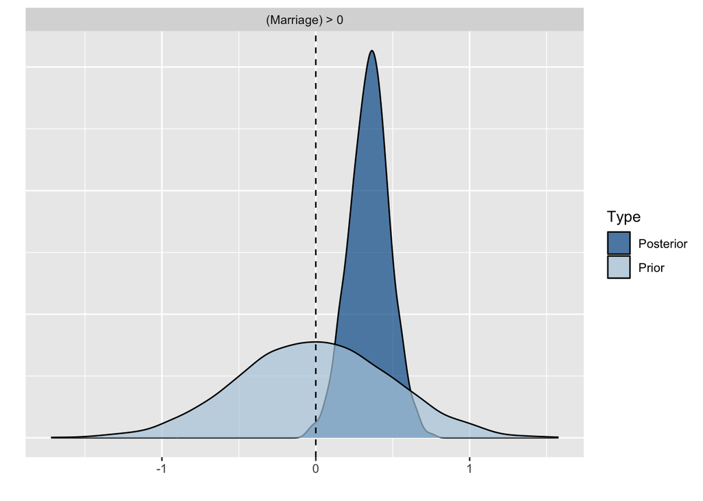

```r
plot(h4.2, plot = FALSE)[[1]] +
  geom_vline(xintercept = 0, linetype = "dashed")
```

##### Posterior prediction plot

In addition to understanding the estimates, it’s important to check the model fit against the observed data.

Here, we plot predicted values versus observed values at data point level:

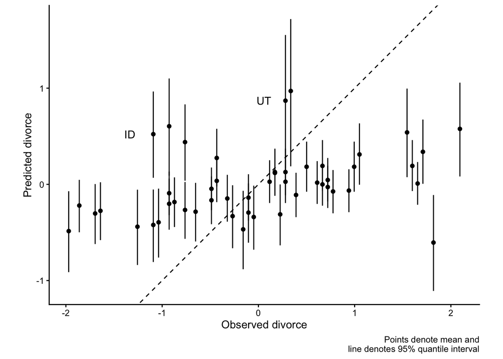

```r
divorce %>%
  add_epred_draws(mod4.2) %>%
  mean_qi() %>%
  ggplot(aes(x = Divorce, y = .epred)) +
  geom_abline(linetype = "dashed") +
  geom_point() +
  geom_linerange(aes(ymin = .lower, ymax = .upper)) +
  geom_text(data = . %>% filter(Loc %in% c("ID", "UT")),
            aes(label = Loc),
            hjust = 0, nudge_x = - 0.3) +
  labs(x = "Observed divorce",
       y = "Predicted divorce",
       caption = "Points denote mean and\nline denotes 95% quantile interval") +
  coord_fixed() +
  theme_classic()
```

##### Predictor residual plots

*A predictor residual is the average prediction error when we use all of the other predictor variables to model a predictor of interest.*

Marriage ~ MedianAgeMarriage.

```r
priors <- c(
  prior("normal(0, 0.2)", class = "Intercept"),
  prior("normal(0, 0.5)", class = "b"),
  prior("normal(0, 1)", class = "sigma")
)
mod4.5 <- brm(
  formula = Marriage ~ MedianAgeMarriage,
  data = divorce,
  family = gaussian(),
  prior = priors,
  chains = 3,
  file = here("models/Marriage~MedianAgeMarriage"),
  sample_prior = "yes"
)
```

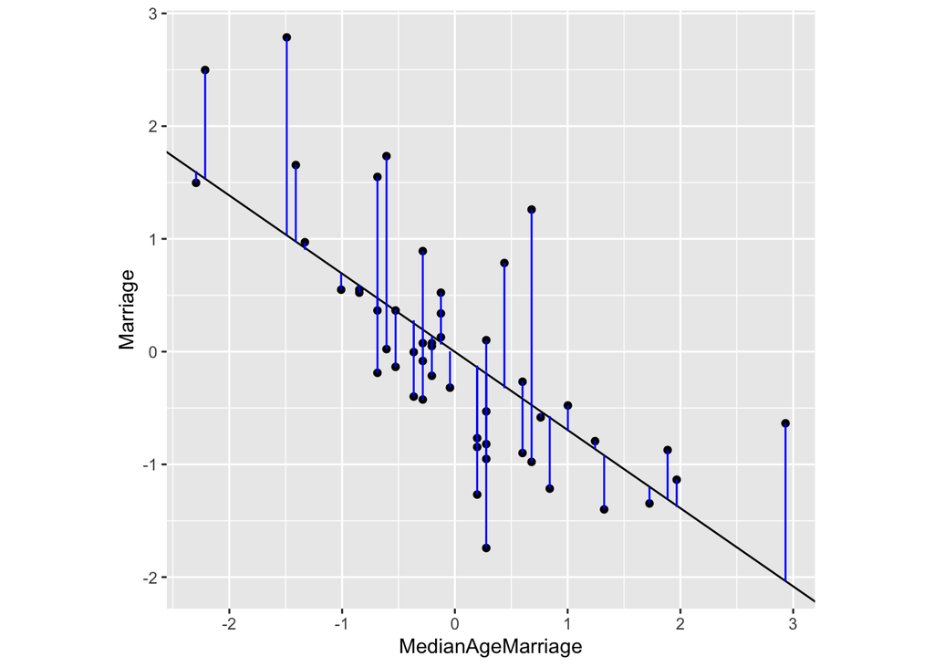

```r
add_residual_draws(divorce, mod4.5) %>%

  mean_qi() %>%

  ggplot(aes(MedianAgeMarriage, Marriage)) +

  geom_point() +

  geom_abline(slope = fixef(mod4.5)[2,1], intercept = fixef(mod4.5)[1,1]) +

  geom_segment(aes(x = MedianAgeMarriage, xend = MedianAgeMarriage,

                   y = Marriage, yend = Marriage - .residual), color = "blue")  +

  coord_fixed()
```

##### Counterfactual plots

Counterfactual plots display the causal implications of the model. They are called counterfactual (relating to or expressing what has not happened or is not the case), because they can be produced for any values of the predictor variables, even unobserved combinations. Basic use would be to observe how the outcome would change as you change one predictor at a time.

Here we generate data for median age of marriage and keeping marriage rate 0. This is a datapoint-level prediction.

```r
priors <- c(
  prior("normal(0, 0.2)", class = "Intercept"),
  prior("normal(0, 0.5)", class = "b"),
  prior("normal(0, 1)", class = "sigma")
)
mod4.3 <- brm(
  formula = Divorce ~ Marriage + MedianAgeMarriage,
  data = divorce,
  family = gaussian(),
  prior = priors,
  chains = 3,
  file = here("models/Divorce~Marriage+MedianAgeMarriage"),
  sample_prior = "yes"
)
```

Here we generate data for marriage rate and keep median age of marriage at 0 (never happens).

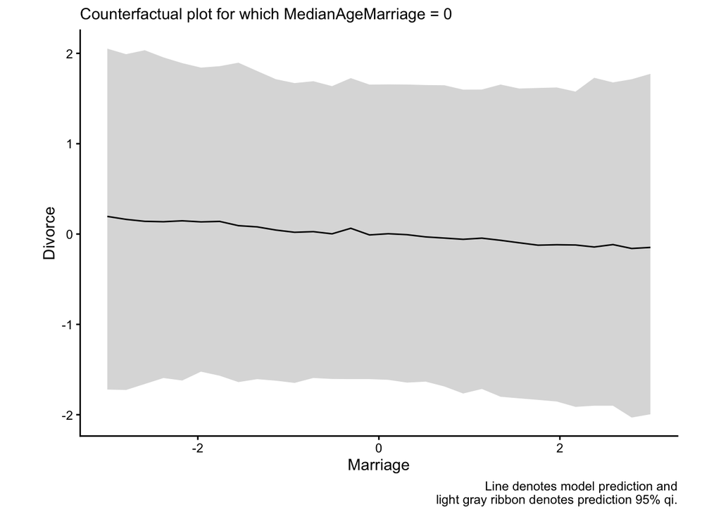

```r
tibble(Marriage = seq(from = -3, to = 3, length.out = 30),
       MedianAgeMarriage = mean(divorce$MedianAgeMarriage)) %>%
  add_predicted_draws(mod4.3) %>%
  mean_qi(.prediction) %>%
  ggplot(aes(Marriage, .prediction)) +
  geom_line() +
  geom_ribbon(aes(ymin = .lower, ymax = .upper), alpha = 1/5) +
  labs(subtitle = "Counterfactual plot for which MedianAgeMarriage = 0",
       y = "Divorce",
       caption = "Line denotes model prediction and\nlight gray ribbon denotes prediction 95% qi.") +
  coord_fixed() +
  theme_classic()
```

Here we generate data for median age of marriage and keeping marriage rate 0. This is a datapoint-level prediction

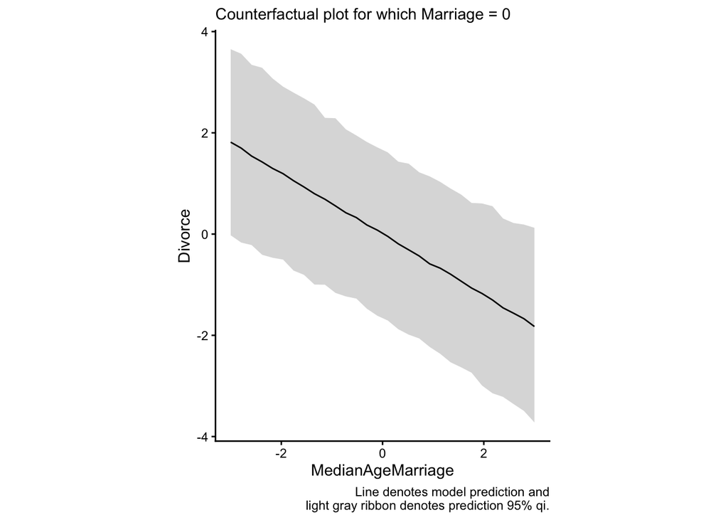

```r
tibble(MedianAgeMarriage = seq(from = -3, to = 3, length.out = 30),
       Marriage = mean(divorce$Marriage)) %>%
  add_predicted_draws(mod4.3) %>%
  mean_qi(.prediction) %>%
  ggplot(aes(MedianAgeMarriage, .prediction)) +
  geom_line() +
  geom_ribbon(aes(ymin = .lower, ymax = .upper), alpha = 1/5) +
  labs(subtitle = "Counterfactual plot for which Marriage = 0",
       y = "Divorce",
       caption = "Line denotes model prediction and\nlight gray ribbon denotes prediction 95% qi.") +
  coord_fixed() +
  theme_classic()
```

```r
conditional_effects(mod4.3, effects = "MedianAgeMarriage", method = "predict")
```

```
## Ignoring unknown labels:
## • fill : "NA"
## • colour : "NA"
## Ignoring unknown labels:
## • fill : "NA"
## • colour : "NA"
```

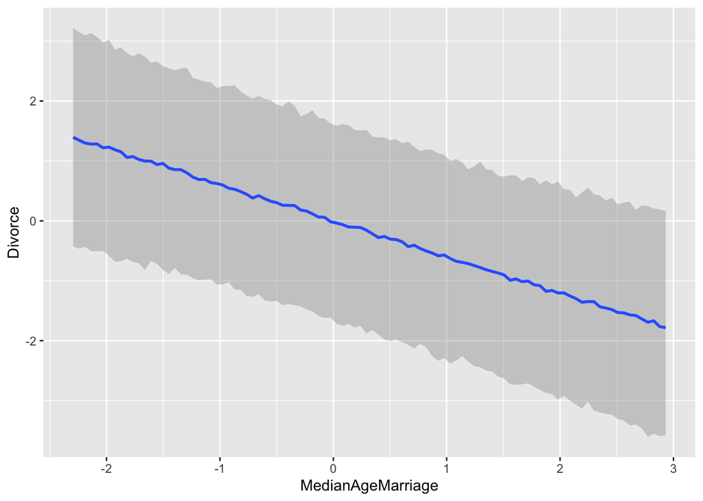

And this is in the level of the predicted mean Divorce rates.

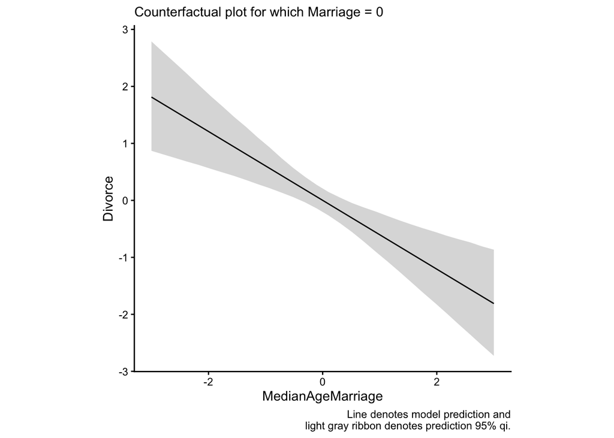

```r
tibble(MedianAgeMarriage = seq(from = -3, to = 3, length.out = 30),
       Marriage = mean(divorce$Marriage)) %>%
  add_epred_draws(mod4.3) %>%
  mean_qi(.epred) %>%
  ggplot(aes(MedianAgeMarriage, .epred)) +
  geom_line() +
  geom_ribbon(aes(ymin = .lower, ymax = .upper), alpha = 1/5) +
  labs(subtitle = "Counterfactual plot for which Marriage = 0",
       y = "Divorce",
       caption = "Line denotes model prediction and\nlight gray ribbon denotes prediction 95% qi.") +
  coord_fixed() +
  theme_classic()
```

method = fitted is the default.

```r
conditional_effects(mod4.3, effects = "MedianAgeMarriage", method = "fitted")
```

```
## Ignoring unknown labels:
## • fill : "NA"
## • colour : "NA"
## Ignoring unknown labels:
## • fill : "NA"
## • colour : "NA"
```

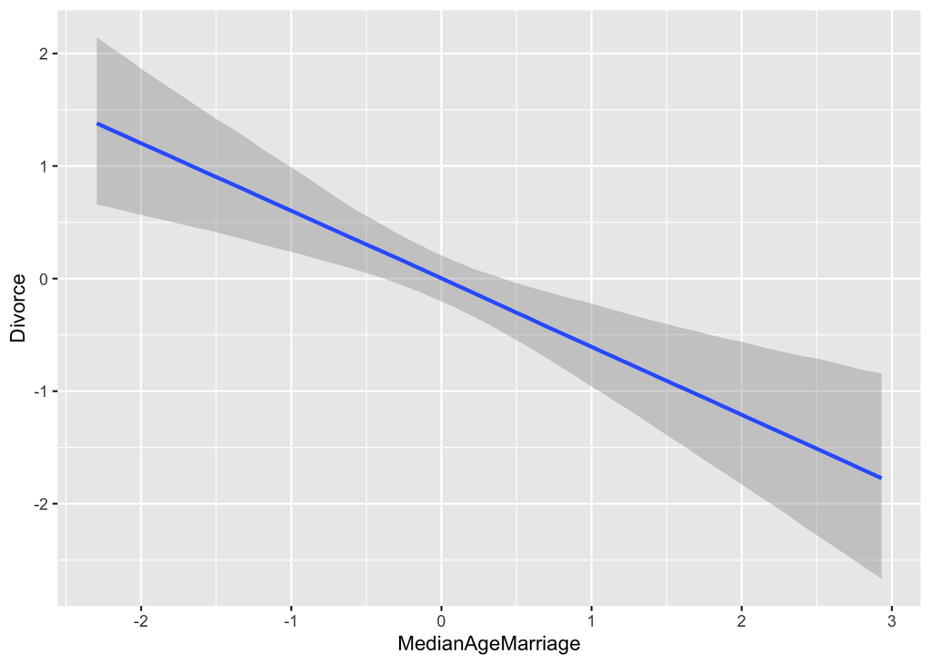

## time course

```r
tapmised <- read_delim("data/tapmised/Sheet 3-Table 1.csv",
    delim = ";", escape_double = FALSE, trim_ws = TRUE)
```

```
## ──────────────────────────────────────────────────────── Delimiter: ";" chr
## (1): ...1 dbl (18): 2003, 2004, 2005, 2006, 2007, 2008, 2009, 2010, 2011, 2012,
## 2013, ...
```

```r
tt <- colSums(tapmised[,-1]) %>% as.data.frame() %>% rownames_to_column()
colnames(tt) <- c("yr", "events")
tt <- tt %>% mutate(yr = parse_number(yr))
```

### Poisson model

```r
mod.pois <- brm(events~yr, tt, family = poisson(), chains = 3, file = "models/mod.pois")
```

```
## Ignoring unknown labels:
## • fill : "NA"
## • colour : "NA"
## Ignoring unknown labels:
## • fill : "NA"
## • colour : "NA"
```

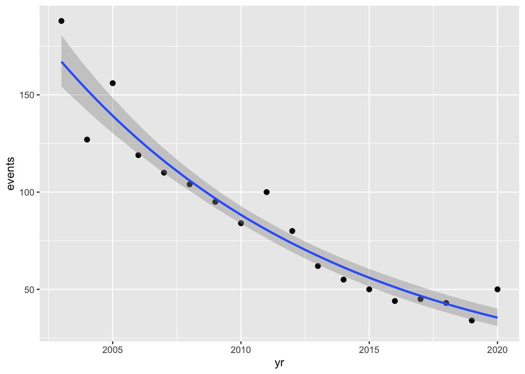

```r
plot(conditional_effects(mod.pois), points=TRUE)
```

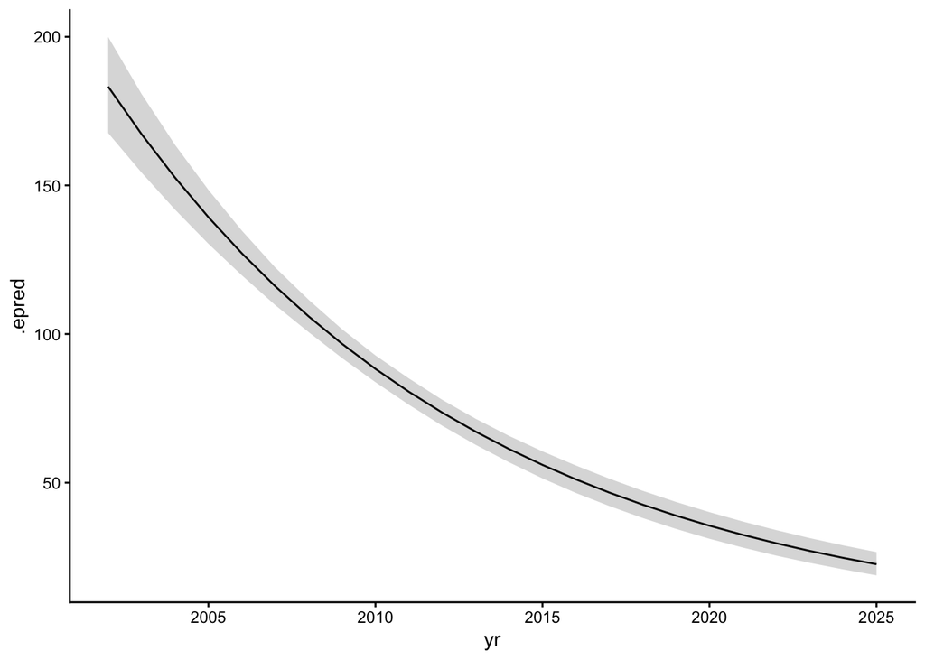

```r
tibble(yr = seq(from = 2002, to = 2025)) %>%
  add_epred_draws(mod.pois) %>%
  mean_qi(.epred) %>%
  ggplot(aes(yr, .epred)) +
  geom_line() +
  geom_ribbon(aes(ymin = .lower, ymax = .upper), alpha = 1/5) +
  theme_classic()
```

### Splines

```r
mod.spl <- brm(events~ s(yr), tt, family = poisson(), chains = 3, file = "models/mod.spl")
```

```
## Ignoring unknown labels:
## • fill : "NA"
## • colour : "NA"
## Ignoring unknown labels:
## • fill : "NA"
## • colour : "NA"
```

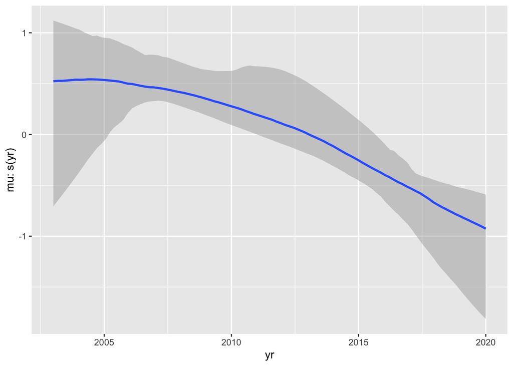

```r
plot(conditional_smooths(mod.spl))
```

```r
conditional_effects(mod.spl)
```

```
## Ignoring unknown labels:
## • fill : "NA"
## • colour : "NA"
## Ignoring unknown labels:
## • fill : "NA"
## • colour : "NA"
```

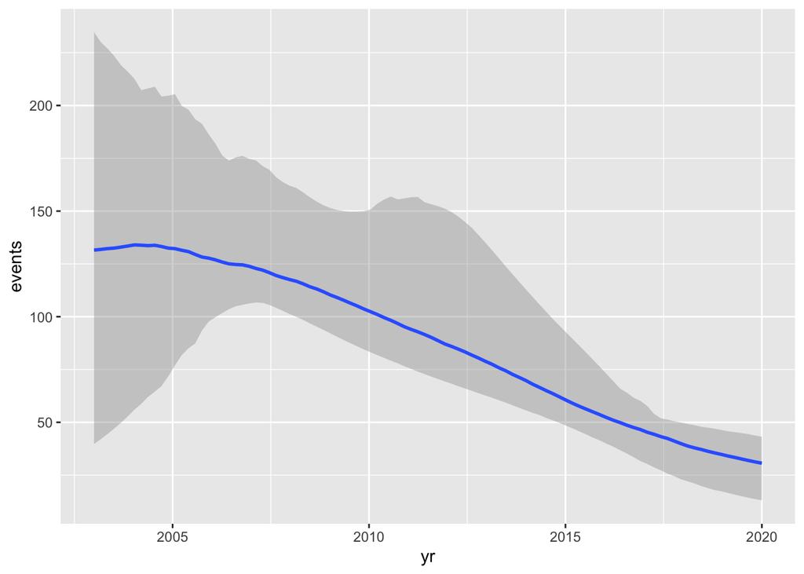

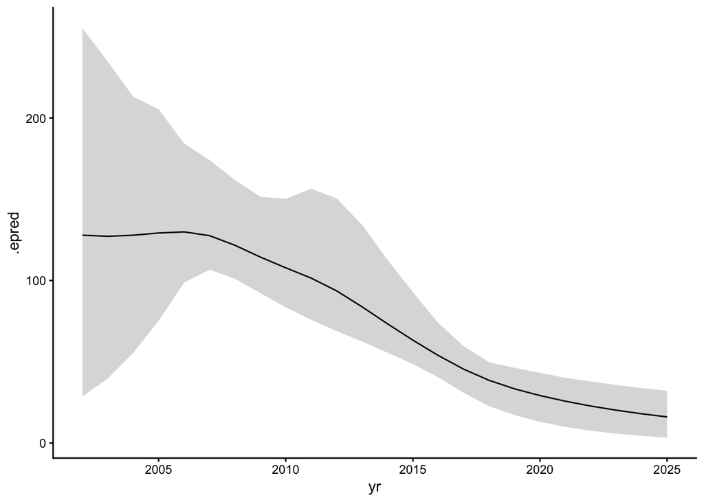

```r
tibble(yr = seq(from = 2002, to = 2025)) %>%
  add_epred_draws(mod.spl) %>%
  mean_qi(.epred) %>%
  ggplot(aes(yr, .epred)) +
  geom_line() +
  geom_ribbon(aes(ymin = .lower, ymax = .upper), alpha = 1/5) +
  theme_classic()
```

```r
mod.spl2 <- brm(events~ yr + s(yr), tt, family = poisson(), chains = 3, file = "models/mod.spl2")
```

```
## Ignoring unknown labels:
## • fill : "NA"
## • colour : "NA"
## Ignoring unknown labels:
## • fill : "NA"
## • colour : "NA"
```

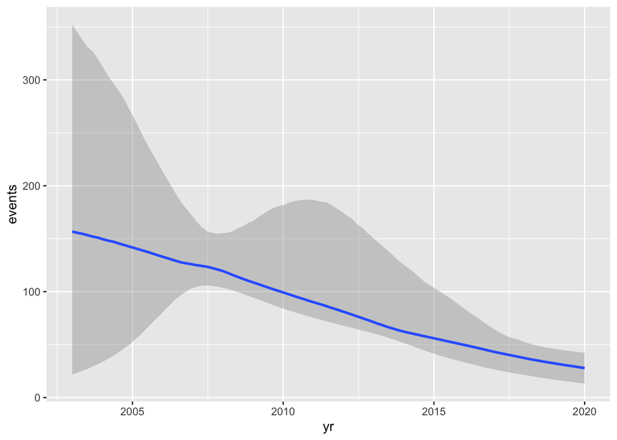

```r
plot(conditional_effects(mod.spl2))
```

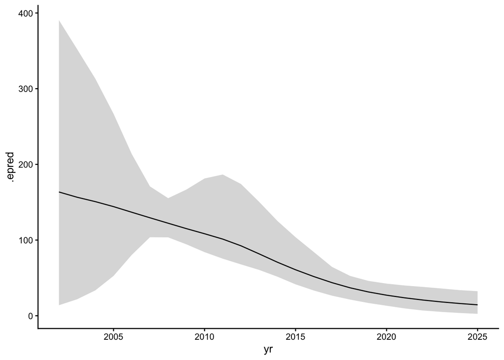

```r
tibble(yr = seq(from = 2002, to = 2025)) %>%
  add_epred_draws(mod.spl2) %>%
  mean_qi(.epred) %>%
  ggplot(aes(yr, .epred)) +
  geom_line() +
  geom_ribbon(aes(ymin = .lower, ymax = .upper), alpha = 1/5) +
  theme_classic()
```

### Gaussian process

While spline models can implement complex nonlinear functions, they are less efficient in modelling effects of covariate interactions. GP is a principled, probabilistic approach to learn non-parametric models, where nonlinearity is implemented through kernels. GPs have become a popular method for non-parametric modelling, especially for time-series data, and a wide variety of kernel functions have been proposed for different modelling tasks. A GP model can be made additive by defining the kernel function to be a sum of kernels. Similarly, a product of two or more kernels is also a valid kernel.

a Gaussian process is a stochastic process (a collection of random variables indexed by time or space), such that every finite collection of those random variables has a multivariate normal distribution, i.e. every finite linear combination of them is normally distributed. The distribution of a Gaussian process is the joint distribution of all those (infinitely many) random variables, and as such, it is a distribution over functions with a continuous domain, e.g. time or space. Gaussian processes can be seen as an infinite-dimensional generalization of multivariate normal distributions. A Gaussian process can be used as a prior probability distribution over functions. For solution of the multi-output prediction problem, Gaussian process regression for vector-valued function was developed. In this method, a ‘big’ covariance is constructed, which describes the correlations between all the input and output variables taken in N points in the desired domain.

Realizations from a GP correspond to random functions and GPs naturally provide a prior for an unknown regression function that is to be estimated from data. GPs differ from standard regression models in that they define priors for entire nonlinear functions, instead of their parameters. While nonlinear effects can be incorporated into standard linear models by extending the basis functions e.g. with higher order polynomials, GPs can automatically detect any nonlinear as well as ns effects without the need of explicitly defining basis functions.

GP models can be made more flexible and interpretable by making them additive, where the kernel (covariance) is a sum of kernels (covariances) and each kernel models the effect of individual covariates or their interactions, i.e. f(x) = f (1)(x) + … + f (D)(x). Intuitively one can think that each GP component f(j) now implements a nonlinear function that specifies the corresponding effect, and the overall effect of several covariates is then the sum of these nonlinear functions. This is achieved by using specific kernels for different types of covariates, such as squared exponential (se) kernel for continuous covariates, constant (co), binary (bi), and categorical (ca) kernels for discrete covariates, and products of these kernels for interaction terms. Moreover, ns signals can be accounted for by incorporating ns kernels.

Covariance (also called the kernel function) of the normal distribution defines the smoothness of the function f, i.e. how fast the regression function can vary. Intuitively speaking, although GP is defined such that any finite- dimensional marginal has a Gaussian distribution, GP regression is a non-parametric method in the sense that the regression function f has no explicit parametric form. More formally, GP contains countably infinite many parameters that define the regression function, which are the function values f at all possible inputs x 2 X.

A Gaussian Peocess is a stochastic process, which describes the relation between one or more predictors x and a response f(x), where d is the number of predictors. A GP is the generalization of the multivariate normal distribution to an infinite number of dimensions. Thus, it can be interpreted as a prior over functions. Any finite sample realized from this stochastic process is jointly multivariate normal, with a covariance matrix defined by the covariance kernel k_p(x), where p is the vector of parameters of the GP:

$$f(x) \sim MVN(0, k_p(x))$$

The smoothness and general behavior of the function f depends only on the choice of covariance kernel

```r
mod.gp <- brm(events~ gp(yr), tt, family = poisson(), chains = 3, file = "models/mod.gp")
```

```r
conditional_effects(mod.gp)
```

```
## Ignoring unknown labels:
## • fill : "NA"
## • colour : "NA"
## Ignoring unknown labels:
## • fill : "NA"
## • colour : "NA"
```

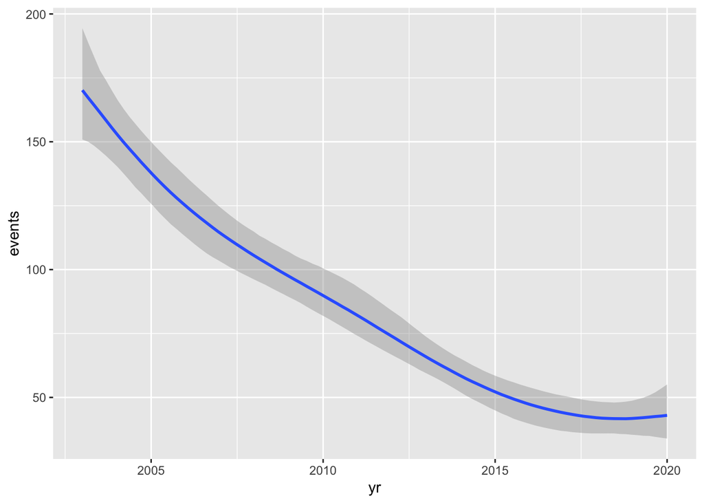

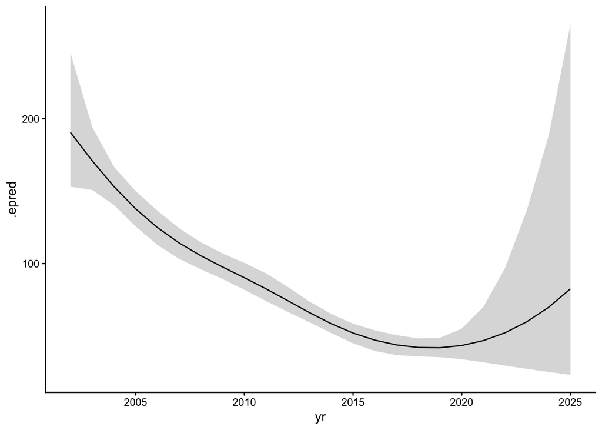

```r
tibble(yr = seq(from = 2002, to = 2025)) %>%
  add_epred_draws(mod.gp) %>%
  mean_qi(.epred) %>%
  ggplot(aes(yr, .epred)) +
  geom_line() +
  geom_ribbon(aes(ymin = .lower, ymax = .upper), alpha = 1/5) +
  theme_classic()
```

```r
mod.gp2 <- brm(events~ yr + gp(yr), tt, family = poisson(), chains = 3, file = "models/mod.gp2")
```

```r
conditional_effects(mod.gp)
```

```
## Ignoring unknown labels:
## • fill : "NA"
## • colour : "NA"
## Ignoring unknown labels:
## • fill : "NA"
## • colour : "NA"
```

[figure not shown]

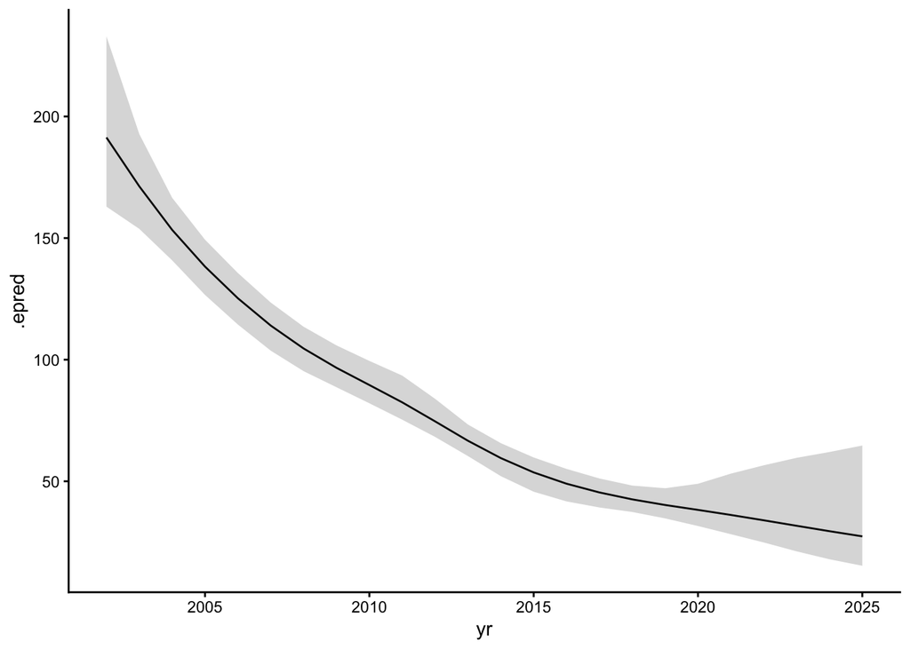

```r
tibble(yr = seq(from = 2002, to = 2025)) %>%
  add_epred_draws(mod.gp2) %>%
  mean_qi(.epred) %>%
  ggplot(aes(yr, .epred)) +
  geom_line() +
  geom_ribbon(aes(ymin = .lower, ymax = .upper), alpha = 1/5) +
  theme_classic()
```